# Final Project - Nhóm 26 - Project 2

## Tải Thư Viện

```r
library(dplyr)
```

```r
library(ggplot2)
library(readr)
library(tidyverse)
library(dplyr)
library(purrr)
library(janitor)
library(themis)
library(e1071)
library(caret)
library(corrplot)
library(skimr)
library(GGally)
library(MASS)
library(pROC)
library(nnet)
library(caret)
library(glmnet)
library(lmPerm)
library(leaps)
library(boot)
library(mice)
library(VIM)
library(car)
library(ipred)
library(splines)
```

## Load Dữ Liệu

```r
data_path <- "diabetes_012_health_indicators_BRFSS2015.csv"

data <- read_csv(data_path, show_col_types = FALSE)
data <- data|> clean_names()

glimpse(data)
```

```
## Rows: 253,680
## Columns: 22
## $ diabetes_012           <dbl> 0, 0, 0, 0, 0, 0, 0, 0, 2, 0, 2, 0, 0, 2, 0, 0,…
## $ high_bp                <dbl> 1, 0, 1, 1, 1, 1, 1, 1, 1, 0, 0, 1, 0, 1, 0, 1,…
## $ high_chol              <dbl> 1, 0, 1, 0, 1, 1, 0, 1, 1, 0, 0, 1, 0, 1, 1, 0,…
## $ chol_check             <dbl> 1, 0, 1, 1, 1, 1, 1, 1, 1, 1, 1, 1, 1, 1, 1, 1,…
## $ bmi                    <dbl> 40, 25, 28, 27, 24, 25, 30, 25, 30, 24, 25, 34,…
## $ smoker                 <dbl> 1, 1, 0, 0, 0, 1, 1, 1, 1, 0, 1, 1, 1, 0, 1, 0,…
## $ stroke                 <dbl> 0, 0, 0, 0, 0, 0, 0, 0, 0, 0, 0, 0, 0, 0, 1, 0,…
## $ heart_diseaseor_attack <dbl> 0, 0, 0, 0, 0, 0, 0, 0, 1, 0, 0, 0, 0, 0, 0, 0,…
## $ phys_activity          <dbl> 0, 1, 0, 1, 1, 1, 0, 1, 0, 0, 1, 0, 0, 0, 1, 1,…
## $ fruits                 <dbl> 0, 0, 1, 1, 1, 1, 0, 0, 1, 0, 1, 1, 0, 0, 0, 0,…
## $ veggies                <dbl> 1, 0, 0, 1, 1, 1, 0, 1, 1, 1, 1, 1, 1, 1, 1, 0,…
## $ hvy_alcohol_consump    <dbl> 0, 0, 0, 0, 0, 0, 0, 0, 0, 0, 0, 0, 0, 0, 0, 0,…
## $ any_healthcare         <dbl> 1, 0, 1, 1, 1, 1, 1, 1, 1, 1, 1, 1, 1, 1, 1, 1,…
## $ no_docbc_cost          <dbl> 0, 1, 1, 0, 0, 0, 0, 0, 0, 0, 0, 0, 0, 0, 1, 0,…
## $ gen_hlth               <dbl> 5, 3, 5, 2, 2, 2, 3, 3, 5, 2, 3, 3, 3, 4, 4, 2,…
## $ ment_hlth              <dbl> 18, 0, 30, 0, 3, 0, 0, 0, 30, 0, 0, 0, 0, 0, 30…
## $ phys_hlth              <dbl> 15, 0, 30, 0, 0, 2, 14, 0, 30, 0, 0, 30, 15, 0,…
## $ diff_walk              <dbl> 1, 0, 1, 0, 0, 0, 0, 1, 1, 0, 0, 1, 0, 1, 0, 0,…
## $ sex                    <dbl> 0, 0, 0, 0, 0, 1, 0, 0, 0, 1, 1, 0, 0, 0, 0, 0,…
## $ age                    <dbl> 9, 7, 9, 11, 11, 10, 9, 11, 9, 8, 13, 10, 7, 11…
## $ education              <dbl> 4, 6, 4, 3, 5, 6, 6, 4, 5, 4, 6, 5, 5, 4, 6, 6,…
## $ income                 <dbl> 3, 1, 8, 6, 4, 8, 7, 4, 1, 3, 8, 1, 7, 6, 2, 8,…
```

#### Kiểm tra dữ liệu thiếu

```r
colSums(is.na(data[1:6]))
```

```
## diabetes_012      high_bp    high_chol   chol_check          bmi       smoker
##            0            0            0            0            0            0
```

```r
colSums(is.na(data[7:9]))
```

```
##                 stroke heart_diseaseor_attack          phys_activity
##                      0                      0                      0
```

```r
colSums(is.na(data[9:12]))
```

```
##       phys_activity              fruits             veggies hvy_alcohol_consump
##                   0                   0                   0                   0
```

```r
colSums(is.na(data[13:17]))
```

```
## any_healthcare  no_docbc_cost       gen_hlth      ment_hlth      phys_hlth
##              0              0              0              0              0
```

```r
colSums(is.na(data[18:22]))
```

```
## diff_walk       sex       age education    income
##         0         0         0         0         0
```

#### Kiểm tra biến và phân loại

```r
cat(names(data), sep = ", ")
```

```
## diabetes_012, high_bp, high_chol, chol_check, bmi, smoker, stroke, heart_diseaseor_attack, phys_activity, fruits, veggies, hvy_alcohol_consump, any_healthcare, no_docbc_cost, gen_hlth, ment_hlth, phys_hlth, diff_walk, sex, age, education, income
```

```r
binary_vars <- names(data)[sapply(data, function(x) length(unique(x)) == 2)]

categorical_vars <- names(data)[sapply(data, function(x) length(unique(x)) > 2 & length(unique(x)) < 20)]

continuous_vars <- names(data)[sapply(data, function(x) is.numeric(x) & length(unique(x)) > 20)]

cat("Biến nhị phân:", paste(binary_vars, collapse  = ", "), "\n\n")
```

```
## Biến nhị phân: high_bp, high_chol, chol_check, smoker, stroke, heart_diseaseor_attack, phys_activity, fruits, veggies, hvy_alcohol_consump, any_healthcare, no_docbc_cost, diff_walk, sex
```

```r
cat("Biến phân loại:", paste(categorical_vars, collapse  = ", "), "\n\n")
```

```
## Biến phân loại: diabetes_012, gen_hlth, age, education, income
```

```r
cat("Biến liên tục:", paste(continuous_vars, collapse  = ", "), "\n\n")
```

```
## Biến liên tục: bmi, ment_hlth, phys_hlth
```

```r
categorical_vars <- setdiff(categorical_vars, "diabetes_012")
target_var <- "diabetes_012"
```

```r
data <- data |> mutate(across(all_of(c(binary_vars, categorical_vars, target_var)), as.factor))

glimpse(data)
```

```
## Rows: 253,680
## Columns: 22
## $ diabetes_012           <fct> 0, 0, 0, 0, 0, 0, 0, 0, 2, 0, 2, 0, 0, 2, 0, 0,…
## $ high_bp                <fct> 1, 0, 1, 1, 1, 1, 1, 1, 1, 0, 0, 1, 0, 1, 0, 1,…
## $ high_chol              <fct> 1, 0, 1, 0, 1, 1, 0, 1, 1, 0, 0, 1, 0, 1, 1, 0,…
## $ chol_check             <fct> 1, 0, 1, 1, 1, 1, 1, 1, 1, 1, 1, 1, 1, 1, 1, 1,…
## $ bmi                    <dbl> 40, 25, 28, 27, 24, 25, 30, 25, 30, 24, 25, 34,…
## $ smoker                 <fct> 1, 1, 0, 0, 0, 1, 1, 1, 1, 0, 1, 1, 1, 0, 1, 0,…
## $ stroke                 <fct> 0, 0, 0, 0, 0, 0, 0, 0, 0, 0, 0, 0, 0, 0, 1, 0,…
## $ heart_diseaseor_attack <fct> 0, 0, 0, 0, 0, 0, 0, 0, 1, 0, 0, 0, 0, 0, 0, 0,…
## $ phys_activity          <fct> 0, 1, 0, 1, 1, 1, 0, 1, 0, 0, 1, 0, 0, 0, 1, 1,…
## $ fruits                 <fct> 0, 0, 1, 1, 1, 1, 0, 0, 1, 0, 1, 1, 0, 0, 0, 0,…
## $ veggies                <fct> 1, 0, 0, 1, 1, 1, 0, 1, 1, 1, 1, 1, 1, 1, 1, 0,…
## $ hvy_alcohol_consump    <fct> 0, 0, 0, 0, 0, 0, 0, 0, 0, 0, 0, 0, 0, 0, 0, 0,…
## $ any_healthcare         <fct> 1, 0, 1, 1, 1, 1, 1, 1, 1, 1, 1, 1, 1, 1, 1, 1,…
## $ no_docbc_cost          <fct> 0, 1, 1, 0, 0, 0, 0, 0, 0, 0, 0, 0, 0, 0, 1, 0,…
## $ gen_hlth               <fct> 5, 3, 5, 2, 2, 2, 3, 3, 5, 2, 3, 3, 3, 4, 4, 2,…
## $ ment_hlth              <dbl> 18, 0, 30, 0, 3, 0, 0, 0, 30, 0, 0, 0, 0, 0, 30…
## $ phys_hlth              <dbl> 15, 0, 30, 0, 0, 2, 14, 0, 30, 0, 0, 30, 15, 0,…
## $ diff_walk              <fct> 1, 0, 1, 0, 0, 0, 0, 1, 1, 0, 0, 1, 0, 1, 0, 0,…
## $ sex                    <fct> 0, 0, 0, 0, 0, 1, 0, 0, 0, 1, 1, 0, 0, 0, 0, 0,…
## $ age                    <fct> 9, 7, 9, 11, 11, 10, 9, 11, 9, 8, 13, 10, 7, 11…
## $ education              <fct> 4, 6, 4, 3, 5, 6, 6, 4, 5, 4, 6, 5, 5, 4, 6, 6,…
## $ income                 <fct> 3, 1, 8, 6, 4, 8, 7, 4, 1, 3, 8, 1, 7, 6, 2, 8,…
```

#### Trực quan hóa phân bố dữ liệu

##### Biến định tính (nhị phân và phân loại)

```r
summary(data[target_var])
```

```
##  diabetes_012
##  0:213703
##  1:  4631
##  2: 35346
```

```r
cat("\n")
```

```r
summary(data[binary_vars[1:6]])
```

```
##  high_bp    high_chol  chol_check smoker     stroke     heart_diseaseor_attack
##  0:144851   0:146089   0:  9470   0:141257   0:243388   0:229787
##  1:108829   1:107591   1:244210   1:112423   1: 10292   1: 23893
```

```r
cat("\n")
```

```r
summary(data[binary_vars[7:11]])
```

```
##  phys_activity fruits     veggies    hvy_alcohol_consump any_healthcare
##  0: 61760      0: 92782   0: 47839   0:239424            0: 12417
##  1:191920      1:160898   1:205841   1: 14256            1:241263
```

```r
cat("\n")
```

```r
summary(data[binary_vars[11:14]])
```

```
##  any_healthcare no_docbc_cost diff_walk  sex
##  0: 12417       0:232326      0:211005   0:141974
##  1:241263       1: 21354      1: 42675   1:111706
```

```r
cat("\n")
```

```r
summary(data[categorical_vars])
```

```
##  gen_hlth       age        education      income
##  1:45299   9      :33244   1:   174   8      :90385
##  2:89084   10     :32194   2:  4043   7      :43219
##  3:75646   8      :30832   3:  9478   6      :36470
##  4:31570   7      :26314   4: 62750   5      :25883
##  5:12081   11     :23533   5: 69910   4      :20135
##            6      :19819   6:107325   3      :15994
##            (Other):87744              (Other):21594
```

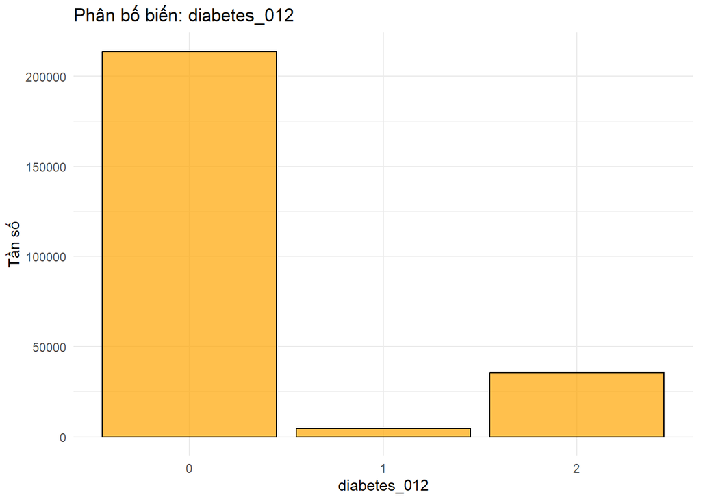

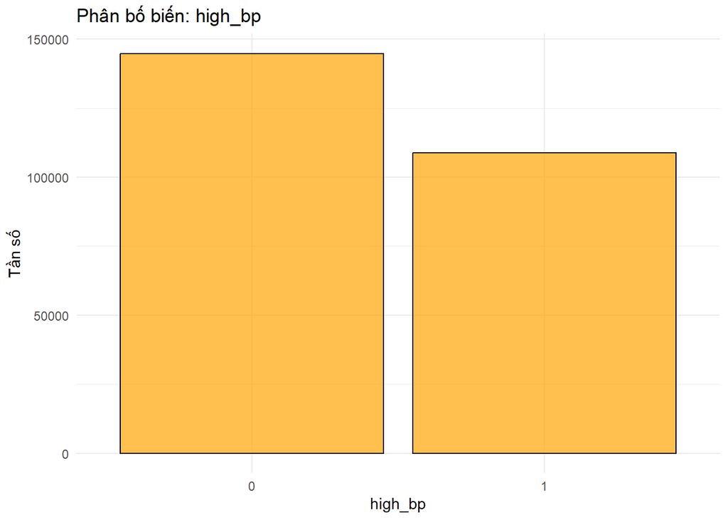

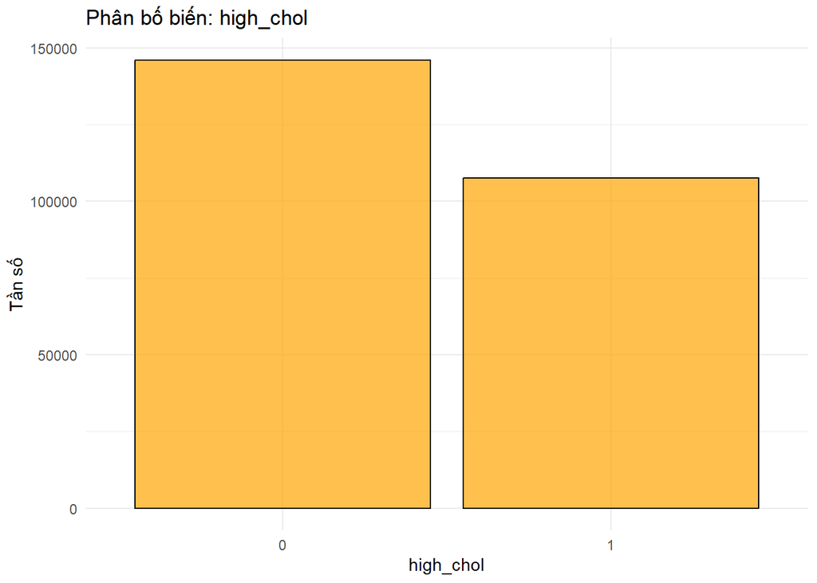

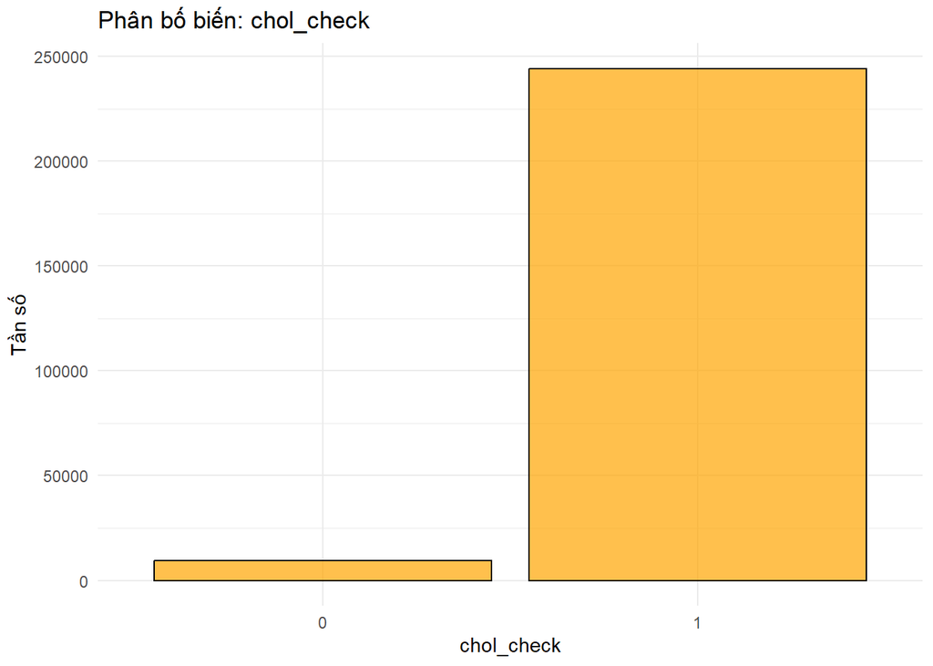

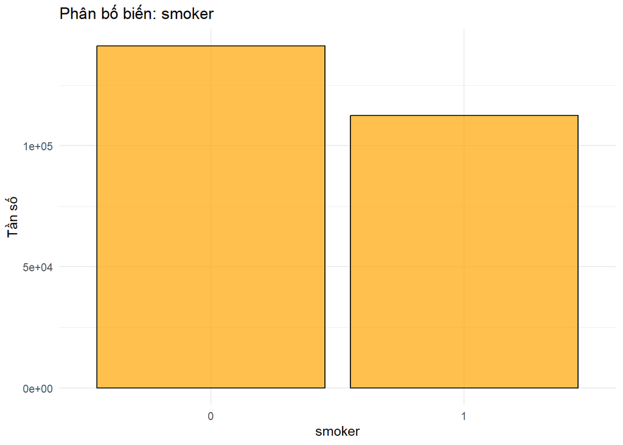

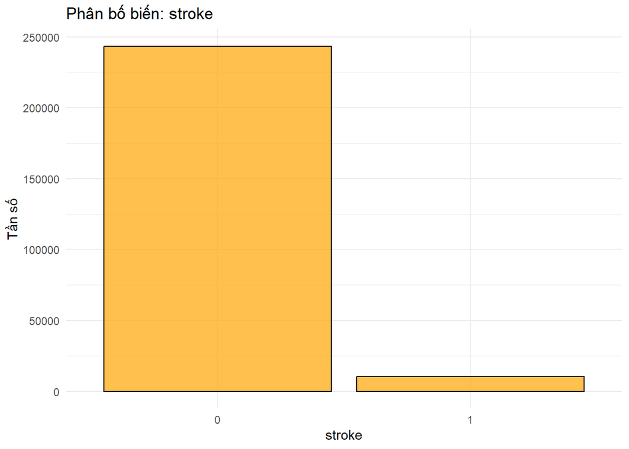

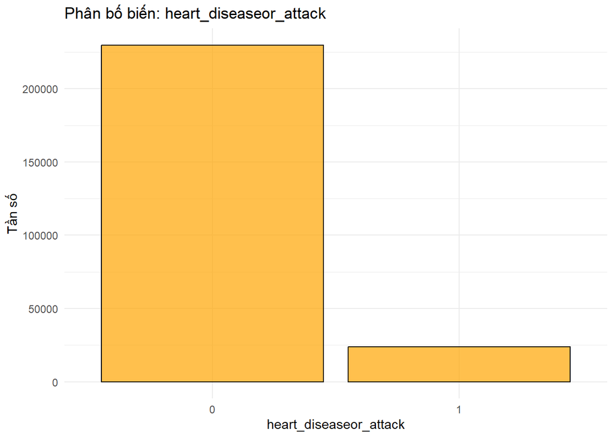

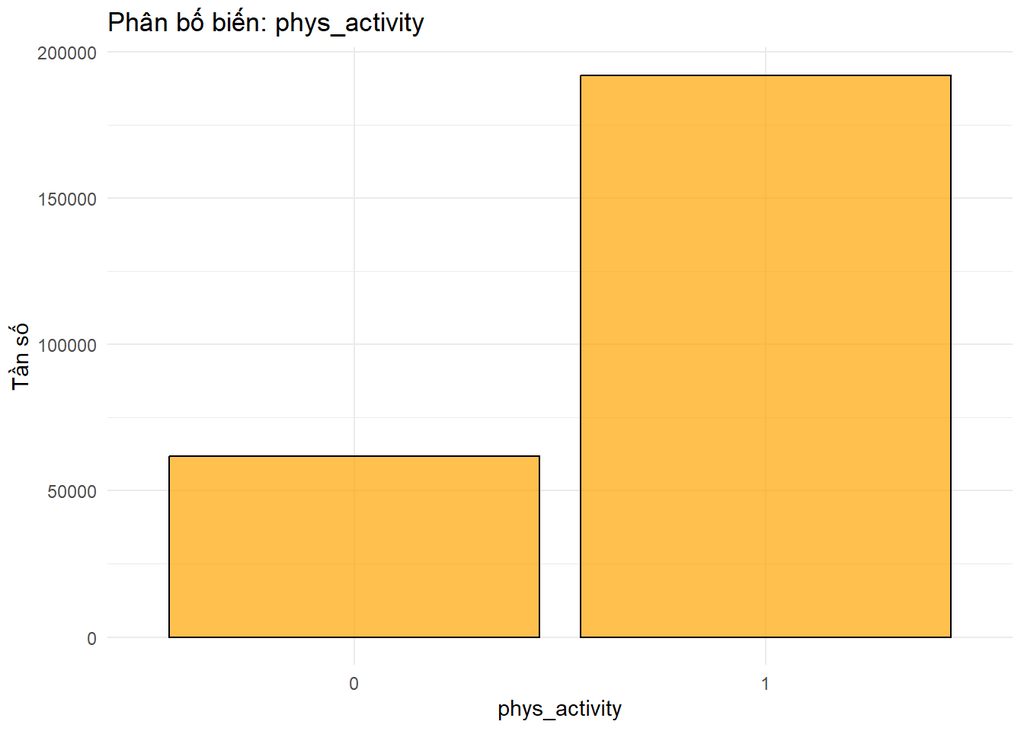

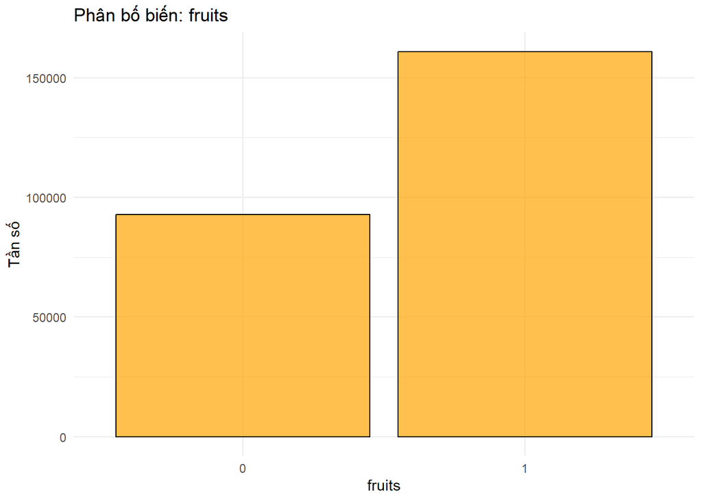

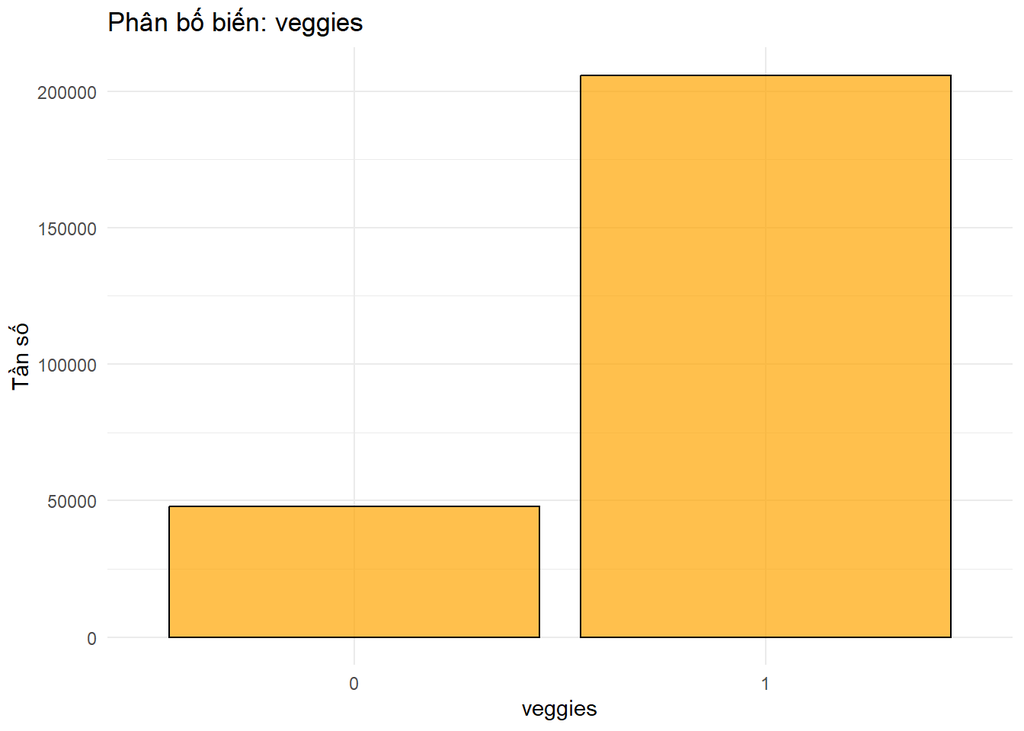

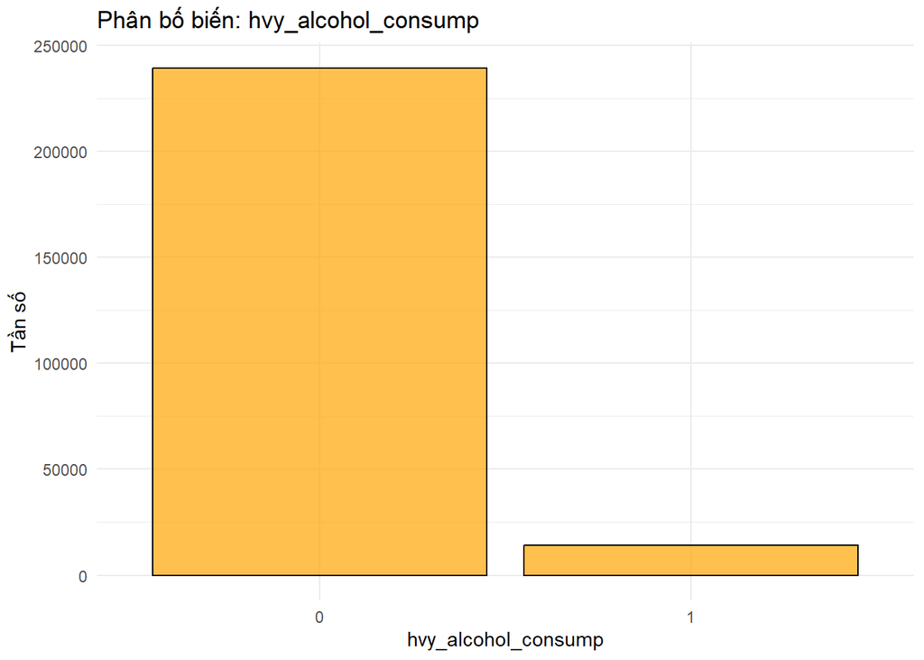

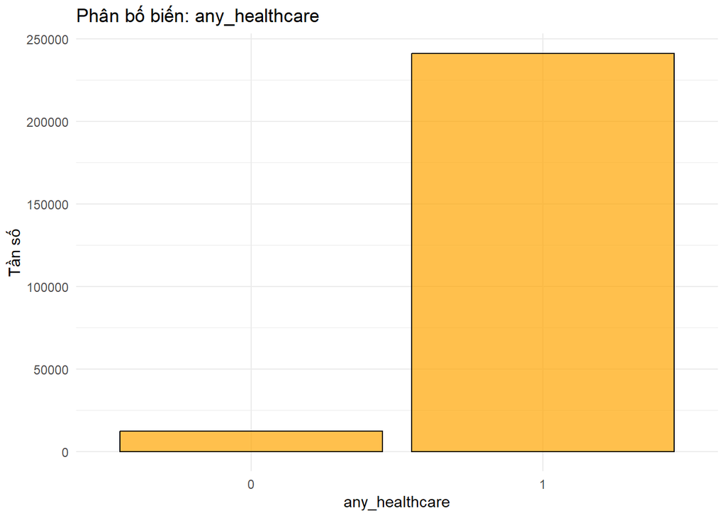

[7 more figures not shown]

```r
c(target_var, binary_vars, categorical_vars)|>
  walk(function(col_name) {
    if (col_name %in% colnames(data)) {
      print(
        ggplot(data, aes_string(x = col_name)) +
          geom_bar(fill = "orange", color = "black", alpha = 0.7) +
          labs(title = paste("Phân bố biến:", col_name), x = col_name, y = "Tần số") +
          theme_minimal()
      )
    }
  })
```

##### Biến định lượng (liên tục)

```r
summary(data[continuous_vars])
```

```
##       bmi          ment_hlth        phys_hlth
##  Min.   :12.00   Min.   : 0.000   Min.   : 0.000
##  1st Qu.:24.00   1st Qu.: 0.000   1st Qu.: 0.000
##  Median :27.00   Median : 0.000   Median : 0.000
##  Mean   :28.38   Mean   : 3.185   Mean   : 4.242
##  3rd Qu.:31.00   3rd Qu.: 2.000   3rd Qu.: 3.000
##  Max.   :98.00   Max.   :30.000   Max.   :30.000
```

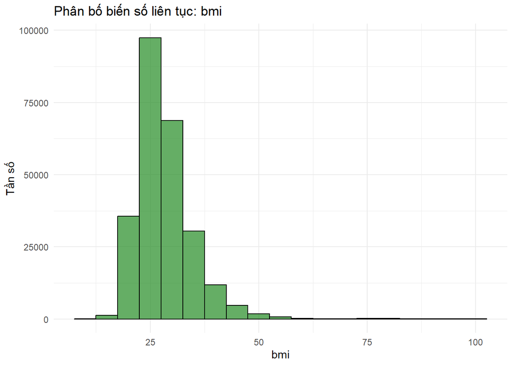

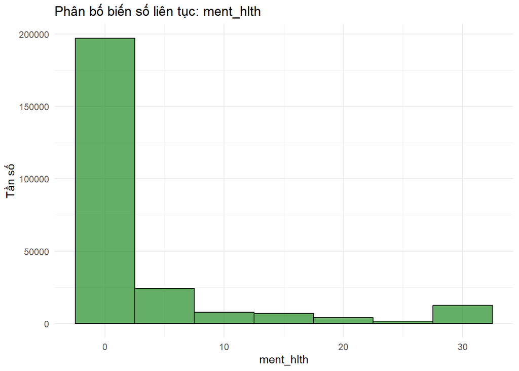

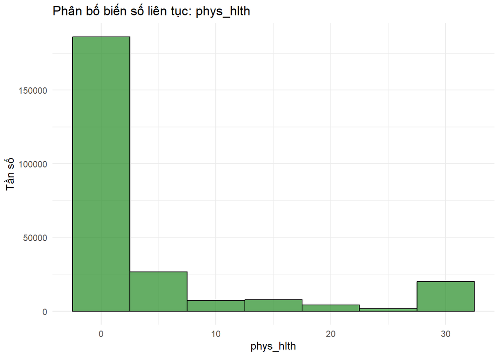

```r
continuous_vars |>
  walk(function(col_name) {
    if (col_name %in% colnames(data)) {
      print(
        ggplot(data, aes_string(x = col_name)) +
          geom_histogram(binwidth = 5, fill = "forestgreen", color = "black", alpha = 0.7) +
          labs(title = paste("Phân bố biến số liên tục:", col_name), x = col_name, y = "Tần số") +
          theme_minimal()
      )
    }
  })
```

## A/B Testing

1. Hàm tính AB testing cho 2 nhóm bằng phương pháp permutation test theo trung bình và tỷ lệ

```r
permutation_test_mean <- function(x, y, R, alter){
  output_list <- list()
  df <- split(x, y)
  nA <- length(df[[1]])
  nB <- length(df[[2]])
  n <- nA + nB
  mean_diff <- numeric(R)
  set.seed(45)
  for (i in 1:R){
    idx_A <- sample(x = 1:n, size = nA)
    idx_B <- setdiff(x = 1:n, y = idx_A)
    mean_diff[i] <- mean(x[idx_A]) - mean(x[idx_B])
  }
  output_list$res_perm <- mean_diff
  meanA <- mean(df[[1]])
  output_list$mean_A <- meanA
  meanB <- mean(df[[2]])
  output_list$mean_B <- meanB
  if (alter == 'left'){ p_value <- mean(mean_diff < (meanA - meanB)) }
  else if (alter == 'right'){ p_value <- mean(mean_diff > (meanA - meanB)) }
  else{ p_value <- mean(abs(mean_diff) > abs(mean1 - mean2)) }
  output_list$p_value <- p_value
  return(output_list)
}

permutation_test_prop <- function(x, y, R, alter){
  output_list <- list()
  df <- split(x, y)
  nA <- length(df[[1]])
  nB <- length(df[[2]])
  n <- nA + nB
  prop_diff <- numeric(R)
  set.seed(45)
  for (i in 1:R){
    idx_A <- sample(x = 1:n, size = nA, replace = TRUE)
    idx_B <- setdiff(x = 1:n, y = idx_A)
    prop_diff[i] <- mean(x[idx_A]==0) - mean(x[idx_B]==0)
  }
  output_list$res_perm <- prop_diff
  propA <- mean(df[[1]]==0)
  output_list$prop_A <- propA
  propB <- mean(df[[2]]==0)
  output_list$prop_B <- propB
  if (alter == 'left'){ p_value <- mean(prop_diff < (propA - propB)) }
  else if (alter == 'right'){ p_value <- mean(prop_diff > (propA - propB)) }
  else{ p_value <- mean(abs(prop_diff) > abs(propA - propB)) }
  output_list$p_value <- p_value
  return(output_list)
}
```

2. Hàm chia nhỏ dữ liệu và tính p-value của mỗi batch

```r
permutation_chisq <- function(x, y, R, batch_size) {
  contingency_table <- table(x, y)
  chi_squared_obs <- chisq.test(contingency_table)$p.value
  chi_squared_permute <- numeric(R)
  num_batches <- ceiling(length(x) / batch_size)
  p_value_permute <- numeric(num_batches)
  for (j in 1:num_batches) {
    df <- data.frame(x = x, y = y)
    df <- sample(df)
    start_idx <- (j - 1) * batch_size + 1
    end_idx <- min(j * batch_size, length(x))
    x_batch <- x[start_idx:end_idx]
    y_batch <- sample(y[start_idx:end_idx])
    contingency_table_batch <- table(x_batch, y_batch)
    p_value_permute[j] <- chisq.test(contingency_table_batch)$p.value
  }
  list(Observed_Chi_Squared = chi_squared_obs,
       P_Value = p_value_permute)
}
```

### 1. Vấn đề sức khỏe và tình trạng bệnh lý

#### 1.1. Biến nhị phân

**Mục tiêu :** Kiểm tra liệu tỷ lệ KHÔNG mắc bệnh tiểu đường có bị ảnh hưởng bởi hai nhóm người mắc và không mắc các vấn đề sức khỏe và tình trạng bệnh lý

**Giả thuyết và Đối thuyết:**
$$H_0 : p_0 = p_1$$

$$H_1 : p_0 \neq p_1$$

**Mức ý nghĩa :** $\alpha = 0.05$

**Mô tả và kiểm chứng :**

```
##
##  high_bp
##          0      1
##   0 134391  79312
##   1   1718   2913
##   2   8742  26604
```

```
##
##  high_chol
##          0      1
##   0 132673  81030
##   1   1756   2875
##   2  11660  23686
```

```
##
##  stroke
##          0      1
##   0 206944   6759
##   1   4366    265
##   2  32078   3268
```

```
##
##  heart_diseaseor_attack
##          0      1
##   0 198352  15351
##   1   3967    664
##   2  27468   7878
```

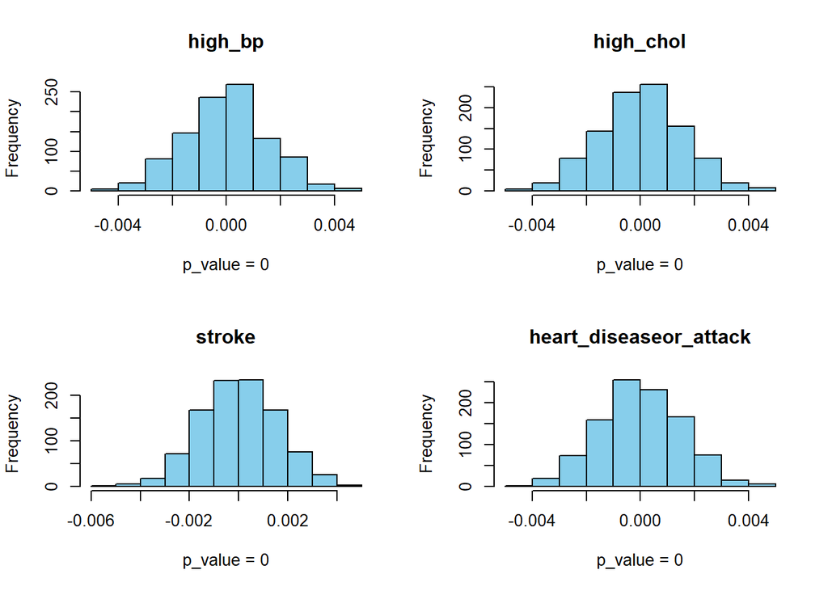

```
##
##  diff_walk
##          0      1
##   0 185434  28269
##   1   3346   1285
##   2  22225  13121
```

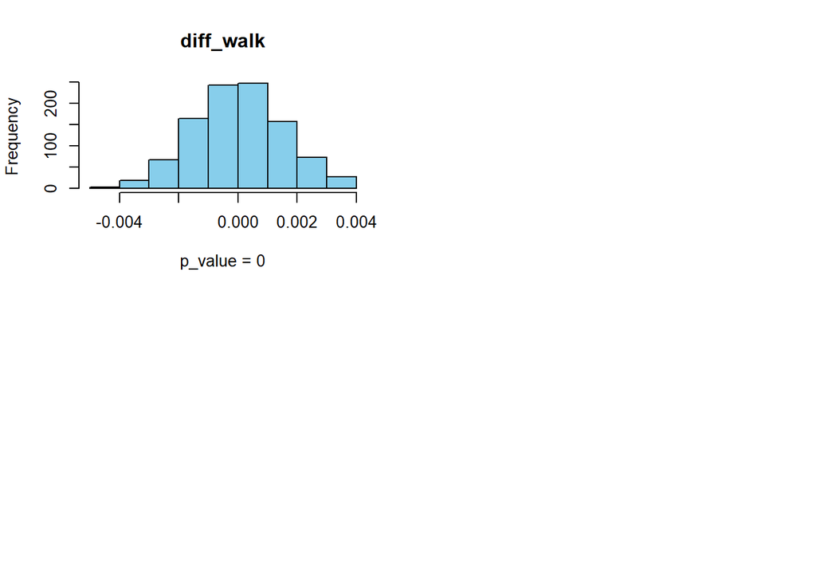

```r
par(mfrow = c(2, 2))
for (name in c('high_bp', 'high_chol', 'stroke', 'heart_diseaseor_attack', 'diff_walk')){
  cat("\n", name)
  print(table(data[[target_var]], data[[name]]))
  res <- permutation_test_prop(data[[target_var]], data[[name]], 1000, "two-sided")

  hist(res$res_perm, col = "skyblue", xlab = paste("p_value =", res$p_value), ylab = "Frequency", main = name)
}
```

**Kết luận :** Với mức ý nghĩa 0.05, bác bỏ được $H_0$ hay các bệnh lý như cao huyết áp, cao cholesterol, đột quỵ, đau tim, khó khăn về vận động đều ảnh hưởng đến tình trạng bệnh tiểu đường.

**Nhận xét :** Người mắc các bệnh lý như trên có nguy cơ cao mắc bệnh tiểu đường hơn người khỏe mạnh.

### 2. Liên quan đến chất lượng cuộc sống và sức khỏe tâm lý

#### 2.1. Biến nhị phân

**Mục tiêu :** Kiểm tra liệu tỷ lệ KHÔNG mắc bệnh tiểu đường có bị ảnh hưởng bởi hai nhóm người có lối sống khác nhau hay không.

**Giả thuyết và Đối thuyết:**
$$H_0 : p_0 = p_1$$

$$H_1 : p_0 \neq p_1$$

**Mức ý nghĩa :** $\alpha = 0.05$

**Mô tả và kiểm chứng :**

```
##
##  smoker
##          0      1
##   0 121879  91824
##   1   2349   2282
##   2  17029  18317
```

```
##
##  hvy_alcohol_consump
##          0      1
##   0 200487  13216
##   1   4423    208
##   2  34514    832
```

```
##
##  no_docbc_cost
##          0      1
##   0 196690  17013
##   1   4032    599
##   2  31604   3742
```

```
##
##  chol_check
##          0      1
##   0   9167 204536
##   1     62   4569
##   2    241  35105
```

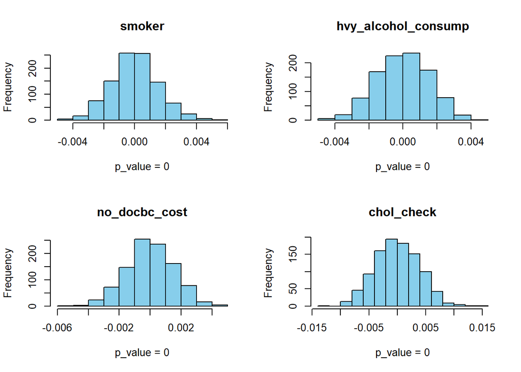

```
##
##  phys_activity
##          0      1
##   0  47212 166491
##   1   1489   3142
##   2  13059  22287
```

```
##
##  fruits
##          0      1
##   0  76287 137416
##   1   1842   2789
##   2  14653  20693
```

```
##
##  veggies
##          0      1
##   0  38159 175544
##   1   1070   3561
##   2   8610  26736
```

```
##
##  any_healthcare
##          0      1
##   0  10741 202962
##   1    254   4377
##   2   1422  33924
```

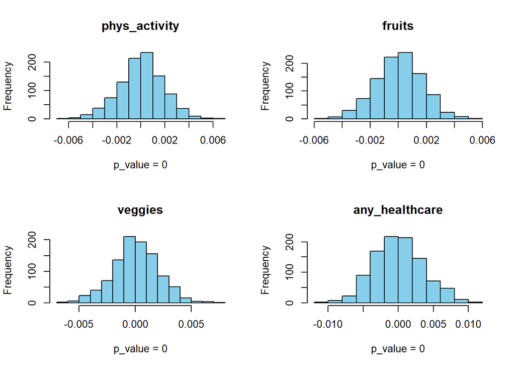

```r
par(mfrow = c(2, 2))
for (name in c('smoker', 'hvy_alcohol_consump', 'no_docbc_cost', 'chol_check', 'phys_activity', 'fruits', 'veggies', 'any_healthcare')){
  cat("\n", name)
  print(table(data[[target_var]], data[[name]]))
  res <- permutation_test_prop(data[[target_var]], data[[name]], 1000, "two-sided")

  hist(res$res_perm, col = "skyblue", xlab = paste("p_value =", res$p_value), ylab = "Frequency", main = name)
}
```

**Kết luận :** Với mức ý nghĩa 0.05, bác bỏ được $H_0$ hay các lối sống tiêu cực và lành mạnh đều ảnh hưởng đáng kể đến tình trạng bệnh tiểu đường

#### 2.2. Biến phân loại

**Mục tiêu :** Kiểm tra liệu tình trạng tiểu đường có phụ thuộc vào điểm tự đánh giá sức khỏe hay không.

**Giả thuyết :** diabetes_012 và gen_hlth độc lập.

**Đối thuyết :** diabetes_012 và gen_hlth không độc lập.

**Mức ý nghĩa :** $\alpha = 0.05$

**Mô tả và kiểm chứng :**

```r
table(data[[target_var]], data$gen_hlth)
```

```
##
##         1     2     3     4     5
##   0 43846 81489 60461 20755  7152
##   1   313  1214  1728  1025   351
##   2  1140  6381 13457  9790  4578
```

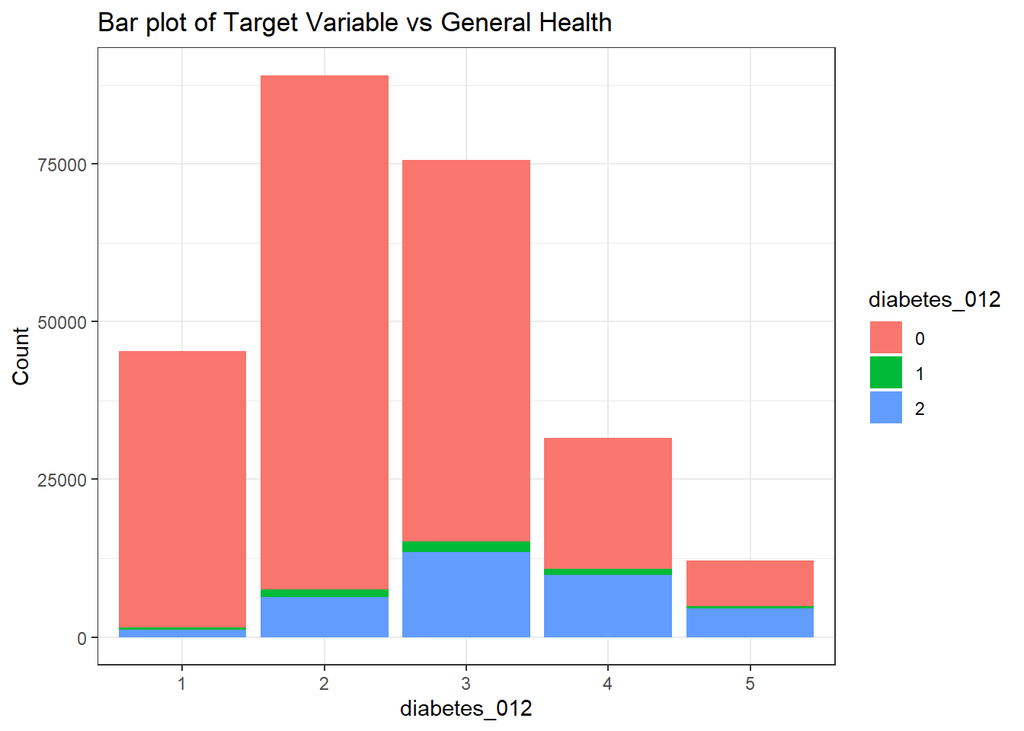

```r
ggplot(data, aes(x = gen_hlth , fill = .data[[target_var]])) +
  geom_bar() +
  labs(x = target_var, y = "Count", title = "Bar plot of Target Variable vs General Health") +
theme_bw()
```

```r
permutation_chisq(data[[target_var]], data$gen_hlth, 1, 13000)
```

```
## $Observed_Chi_Squared
## [1] 0
##
## $P_Value
##  [1] 0.2131673 0.2373865 0.5017810 0.9986350 0.5218465 0.8741609 0.3733506
##  [8] 0.7128793 0.3204125 0.5075115 0.7822930 0.9443713 0.3144614 0.1012737
## [15] 0.2504138 0.6468666 0.1035610 0.1253995 0.2291763 0.5569559
```

### 3. Vấn đề về nhân khẩu học

#### 3.1. Biến nhị phân

**Mục tiêu :** Kiểm tra liệu tỷ lệ KHÔNG mắc bệnh tiểu đường có bị ảnh hưởng bởi hai giới tính sinh học không.

**Giả thuyết và Đối thuyết:**
$$H_0 : p_0 = p_1$$

$$H_1 : p_0 \neq p_1$$

**Mức ý nghĩa :** $\alpha = 0.05$

**Mô tả và kiểm chứng :**

```r
table(data[[target_var]], data$sex)
```

```
##
##          0      1
##   0 120959  92744
##   1   2604   2027
##   2  18411  16935
```

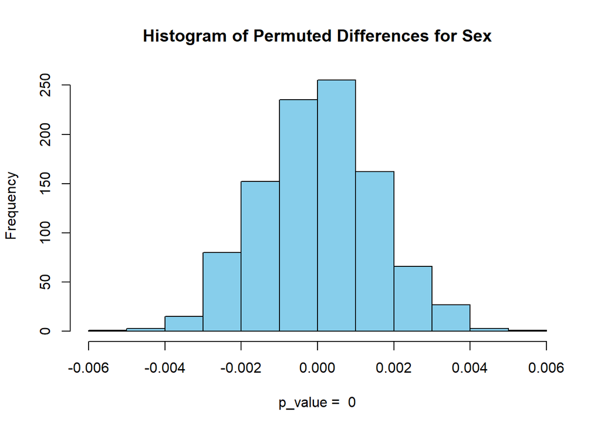

```r
res <- permutation_test_prop(data[[target_var]], data$sex, 1000, "two-sided")

hist(res$res_perm, col = "skyblue", xlab = paste("p_value = ", res$p_value), ylab = "Frequency", main = paste("Histogram of Permuted Differences for Sex"))
```

**Kết luận :** với mức ý nghĩa 0.05, bác bỏ được $H_0$ hay ta nói, giới tính có ảnh hưởng đến tình trạng bệnh tiểu đường.

#### 3.2. Biến phân loại

**Mục tiêu :** Kiểm tra liệu tỷ lệ mắc bệnh tiểu đường có bị phụ thuộc vào các nhóm tuổi, các nhóm trình độ giáo dục hay các nhóm có mức thu nhập khác nhau hay không.

**Giả thuyết :** diabetes_012 độc lập với age, education, income.

**Đối thuyết :** diabetes_012 không độc lập với age, education, income.

**Mức ý nghĩa :** $\alpha = 0.05$

**Mô tả và kiểm chứng :**

```r
par(mfrow = c(2, 2))
for (name in c('age', 'education', 'income')){
  cat("\n", name)
  print(table(data[[target_var]], data[[name]]))
}
```

```
##
##  age
##         1     2     3     4     5     6     7     8     9    10    11    12
##   0  5601  7404 10737 13055 14943 17765 22808 26019 26809 24939 17790 12132
##   1    21    54    72   142   163   312   418   550   702   697   602   445
##   2    78   140   314   626  1051  1742  3088  4263  5733  6558  5141  3403
##
##        13
##   0 13701
##   1   453
##   2  3209
##
##  education
##         1     2     3     4     5     6
##   0   125  2699  6868 50334 58223 95454
##   1     2   161   314  1350  1333  1471
##   2    47  1183  2296 11066 10354 10400
##
##  income
##         1     2     3     4     5     6     7     8
##   0  7114  8341 12005 15622 20792 30431 37219 82179
##   1   314   356   421   459   587   748   735  1011
##   2  2383  3086  3568  4054  4504  5291  5265  7195
```

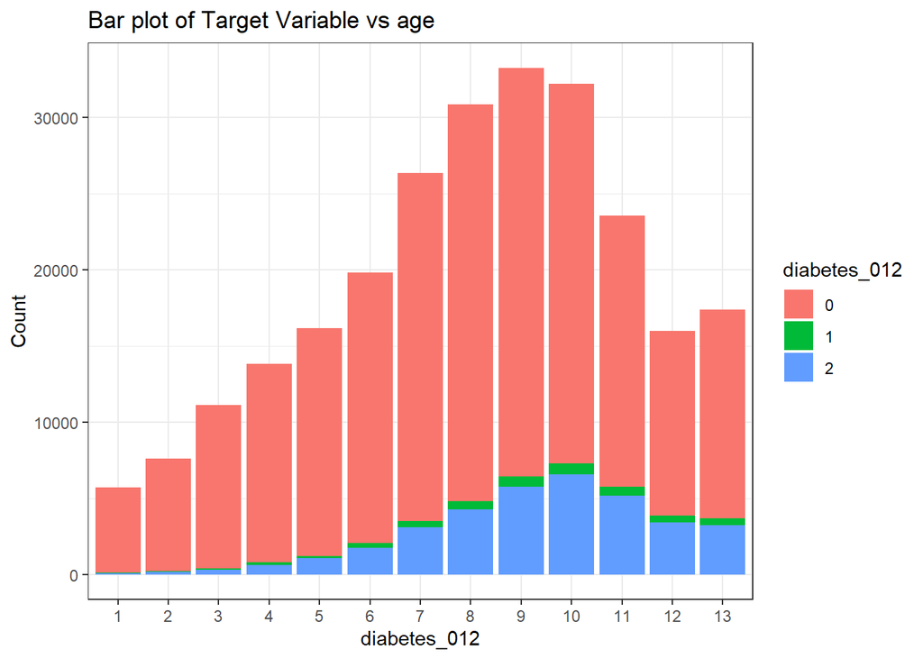

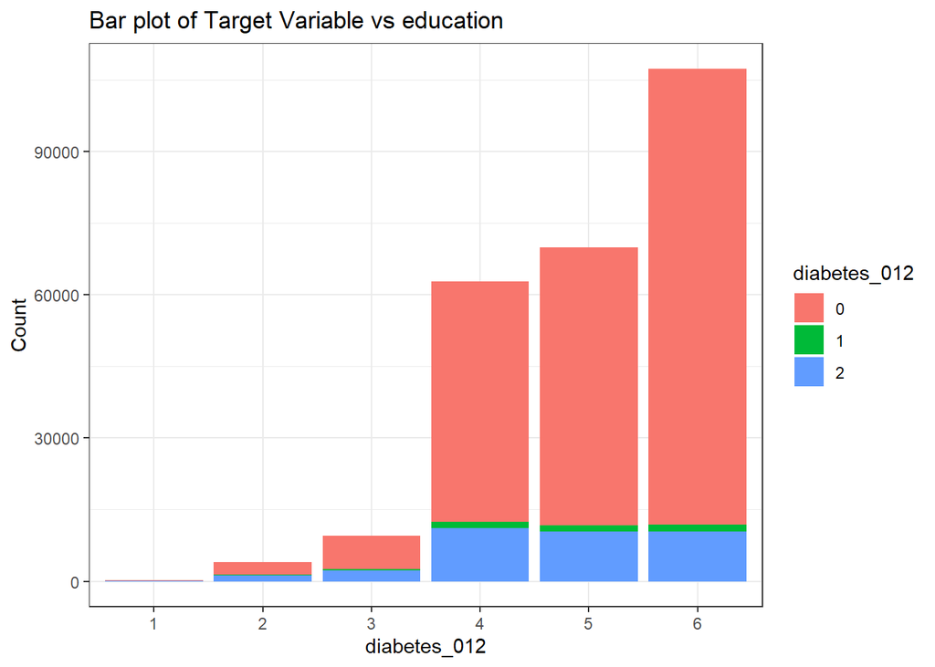

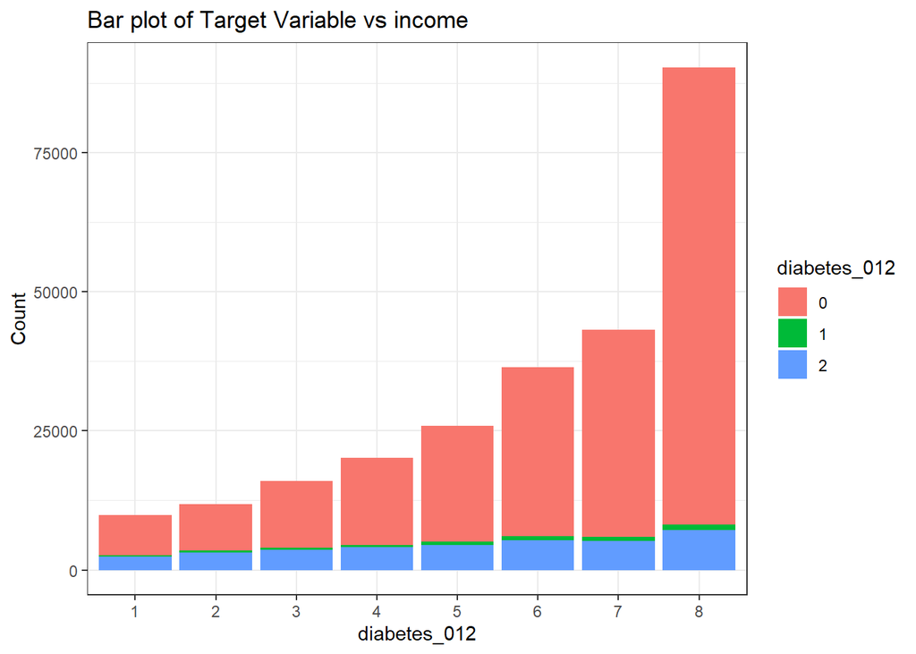

```r
for (name in c('age', 'education', 'income')){
  p <- ggplot(data, aes(x = .data[[name]], fill = .data[[target_var]])) +
  geom_bar() +
  labs(x = target_var, y = "Count", title = paste("Bar plot of Target Variable vs", name)) +
theme_bw()
  print(p)
}
```

```r
permutation_chisq(data[[target_var]], data$age, 1, 13000)
```

```
## $Observed_Chi_Squared
## [1] 0
##
## $P_Value
##  [1] 0.4673229 0.4366795 0.9824604 0.8652582 0.6977366 0.9356220 0.7899368
##  [8] 0.7959886 0.7318394 0.6315256 0.6554614 0.1171794 0.3258763 0.8827392
## [15] 0.7625083 0.6240613 0.6901123 0.0928221 0.7348921 0.8710869
```

```r
permutation_chisq(data[[target_var]], data$education, 1, 13000)
```

[output not shown]

```
## $Observed_Chi_Squared
## [1] 0
##
## $P_Value
##  [1] 0.2226812 0.2785799 0.9118701 0.1160726 0.5751922 0.6298231 0.2334798
##  [8] 0.6100299 0.3994861 0.2600380 0.5368048 0.9888411 0.9135225 0.4860685
## [15] 0.9179170 0.7116613 0.1623227 0.5095206 0.6320245 0.3697091
```

```r
permutation_chisq(data[[target_var]], data$income, 1, 13000)
```

```
## $Observed_Chi_Squared
## [1] 0
##
## $P_Value
##  [1] 0.797049480 0.007617191 0.663850746 0.613654961 0.251712155 0.118684977
##  [7] 0.912107347 0.297656751 0.980442091 0.057461813 0.453054424 0.486423885
## [13] 0.063224037 0.644244533 0.846199978 0.453210901 0.926493160 0.542276484
## [19] 0.625124688 0.293003539
```

# B. Hồi quy

## 1. Tải dữ liệu

```r
data <- read.csv("diabetes_012_health_indicators_BRFSS2015.csv")
data <- data |> janitor::clean_names()
data_no_diabetes <- data[, names(data) != "diabetes_012"]
glimpse(data_no_diabetes)
```

```
## Rows: 253,680
## Columns: 21
## $ high_bp                <dbl> 1, 0, 1, 1, 1, 1, 1, 1, 1, 0, 0, 1, 0, 1, 0, 1,…
## $ high_chol              <dbl> 1, 0, 1, 0, 1, 1, 0, 1, 1, 0, 0, 1, 0, 1, 1, 0,…
## $ chol_check             <dbl> 1, 0, 1, 1, 1, 1, 1, 1, 1, 1, 1, 1, 1, 1, 1, 1,…
## $ bmi                    <dbl> 40, 25, 28, 27, 24, 25, 30, 25, 30, 24, 25, 34,…
## $ smoker                 <dbl> 1, 1, 0, 0, 0, 1, 1, 1, 1, 0, 1, 1, 1, 0, 1, 0,…
## $ stroke                 <dbl> 0, 0, 0, 0, 0, 0, 0, 0, 0, 0, 0, 0, 0, 0, 1, 0,…
## $ heart_diseaseor_attack <dbl> 0, 0, 0, 0, 0, 0, 0, 0, 1, 0, 0, 0, 0, 0, 0, 0,…
## $ phys_activity          <dbl> 0, 1, 0, 1, 1, 1, 0, 1, 0, 0, 1, 0, 0, 0, 1, 1,…
## $ fruits                 <dbl> 0, 0, 1, 1, 1, 1, 0, 0, 1, 0, 1, 1, 0, 0, 0, 0,…
## $ veggies                <dbl> 1, 0, 0, 1, 1, 1, 0, 1, 1, 1, 1, 1, 1, 1, 1, 0,…
## $ hvy_alcohol_consump    <dbl> 0, 0, 0, 0, 0, 0, 0, 0, 0, 0, 0, 0, 0, 0, 0, 0,…
## $ any_healthcare         <dbl> 1, 0, 1, 1, 1, 1, 1, 1, 1, 1, 1, 1, 1, 1, 1, 1,…
## $ no_docbc_cost          <dbl> 0, 1, 1, 0, 0, 0, 0, 0, 0, 0, 0, 0, 0, 0, 1, 0,…
## $ gen_hlth               <dbl> 5, 3, 5, 2, 2, 2, 3, 3, 5, 2, 3, 3, 3, 4, 4, 2,…
## $ ment_hlth              <dbl> 18, 0, 30, 0, 3, 0, 0, 0, 30, 0, 0, 0, 0, 0, 30…
## $ phys_hlth              <dbl> 15, 0, 30, 0, 0, 2, 14, 0, 30, 0, 0, 30, 15, 0,…
## $ diff_walk              <dbl> 1, 0, 1, 0, 0, 0, 0, 1, 1, 0, 0, 1, 0, 1, 0, 0,…
## $ sex                    <dbl> 0, 0, 0, 0, 0, 1, 0, 0, 0, 1, 1, 0, 0, 0, 0, 0,…
## $ age                    <dbl> 9, 7, 9, 11, 11, 10, 9, 11, 9, 8, 13, 10, 7, 11…
## $ education              <dbl> 4, 6, 4, 3, 5, 6, 6, 4, 5, 4, 6, 5, 5, 4, 6, 6,…
## $ income                 <dbl> 3, 1, 8, 6, 4, 8, 7, 4, 1, 3, 8, 1, 7, 6, 2, 8,…
```

## 2. Kiểm tra dữ liệu

### 2.1 Kiểm tra dữ liệu khuyết

```r
missing_values <- colSums(is.na(data_no_diabetes))
print("Số lượng giá trị khuyết ở mỗi cột:")
```

```
## [1] "Số lượng giá trị khuyết ở mỗi cột:"
```

```r
print(missing_values)
```

```
##                high_bp              high_chol             chol_check
##                      0                      0                      0
##                    bmi                 smoker                 stroke
##                      0                      0                      0
## heart_diseaseor_attack          phys_activity                 fruits
##                      0                      0                      0
##                veggies    hvy_alcohol_consump         any_healthcare
##                      0                      0                      0
##          no_docbc_cost               gen_hlth              ment_hlth
##                      0                      0                      0
##              phys_hlth              diff_walk                    sex
##                      0                      0                      0
##                    age              education                 income
##                      0                      0                      0
```

Số lượng giá trị thiếu ở mỗi cột = 0 => Không cần xử lí dữ liệu khuyết

### 2.2 Kiểm tra sự tương quan

```r
# Vẽ ma trận tương quan giữa các biến
cor_matrix <- cor(data_no_diabetes)
print("Ma trận tương quan của dữ liệu:")
```

```
## [1] "Ma trận tương quan của dữ liệu:"
```

```r
print(cor_matrix)
```

```
##                             high_bp   high_chol   chol_check         bmi
## high_bp                 1.000000000  0.29819930  0.098508273  0.21374812
## high_chol               0.298199295  1.00000000  0.085642228  0.10672208
## chol_check              0.098508273  0.08564223  1.000000000  0.03449509
## bmi                     0.213748120  0.10672208  0.034495087  1.00000000
## smoker                  0.096991467  0.09129936 -0.009928878  0.01380447
## stroke                  0.129574913  0.09262007  0.024157667  0.02015266
## heart_diseaseor_attack  0.209361211  0.18076535  0.044205810  0.05290426
## phys_activity          -0.125266866 -0.07804619  0.004189617 -0.14729363
## fruits                 -0.040554659 -0.04085908  0.023849406 -0.08751812
## veggies                -0.061266165 -0.03987361  0.006121010 -0.06227519
## hvy_alcohol_consump    -0.003971574 -0.01154252 -0.023730091 -0.04873628
## any_healthcare          0.038424769  0.04222986  0.117625625 -0.01847079
## no_docbc_cost           0.017357984  0.01331016 -0.058255084  0.05820629
## gen_hlth                0.300529631  0.20842555  0.046588865  0.23918537
## ment_hlth               0.056455917  0.06206915 -0.008365598  0.08531016
## phys_hlth               0.161211571  0.12175053  0.031774808  0.12114111
## diff_walk               0.223618466  0.14467154  0.040585057  0.19707776
## sex                     0.052206961  0.03120533 -0.022115036  0.04295030
## age                     0.344452330  0.27231823  0.090321114 -0.03661764
## education              -0.141357934 -0.07080189  0.001510491 -0.10393202
## income                 -0.171234581 -0.08545931  0.014258747 -0.10006871
##                              smoker       stroke heart_diseaseor_attack
## high_bp                 0.096991467  0.129574913             0.20936121
## high_chol               0.091299357  0.092620074             0.18076535
## chol_check             -0.009928878  0.024157667             0.04420581
## bmi                     0.013804467  0.020152661             0.05290426
## smoker                  1.000000000  0.061172675             0.11444122
## stroke                  0.061172675  1.000000000             0.20300194
## heart_diseaseor_attack  0.114441218  0.203001940             1.00000000
## phys_activity          -0.087401163 -0.069151416            -0.08729899
## fruits                 -0.077665839 -0.013389353            -0.01979035
## veggies                -0.030677710 -0.041124225            -0.03916741
## hvy_alcohol_consump     0.101618687 -0.016950330            -0.02899052
## any_healthcare         -0.023250803  0.008775925             0.01873419
## no_docbc_cost           0.048945823  0.034804106             0.03099970
## gen_hlth                0.163143067  0.177942260             0.25838341
## ment_hlth               0.092196474  0.070171812             0.06462129
## phys_hlth               0.116459714  0.148944169             0.18169754
## diff_walk               0.122463215  0.176566917             0.21270870
```

[output cut: 77 more lines]

```
## heart_diseaseor_attack  0.086095508  0.221617632 -0.099599915 -0.14101123
## phys_activity           0.032481686 -0.092510633  0.199658057  0.19853946
## fruits                 -0.091174865  0.064547217  0.110187097  0.07992931
## veggies                -0.064765156 -0.009771198  0.154329262  0.15108694
## hvy_alcohol_consump     0.005740219 -0.034577637  0.023996867  0.05361857
## any_healthcare         -0.019405465  0.138045679  0.122514239  0.15799928
## no_docbc_cost          -0.044931366 -0.119777068 -0.100701002 -0.20318237
## gen_hlth               -0.006091004  0.152449830 -0.284911532 -0.37001373
## ment_hlth              -0.080704863 -0.092068024 -0.101829695 -0.20980613
## phys_hlth              -0.043136502  0.099129925 -0.155092517 -0.26679896
## diff_walk              -0.070298902  0.204450090 -0.192642100 -0.32012424
## sex                     1.000000000 -0.027340383  0.019479786  0.12714106
## age                    -0.027340383  1.000000000 -0.101901070 -0.12777528
## education               0.019479786 -0.101901070  1.000000000  0.44910642
## income                  0.127141058 -0.127775278  0.449106424  1.00000000
```

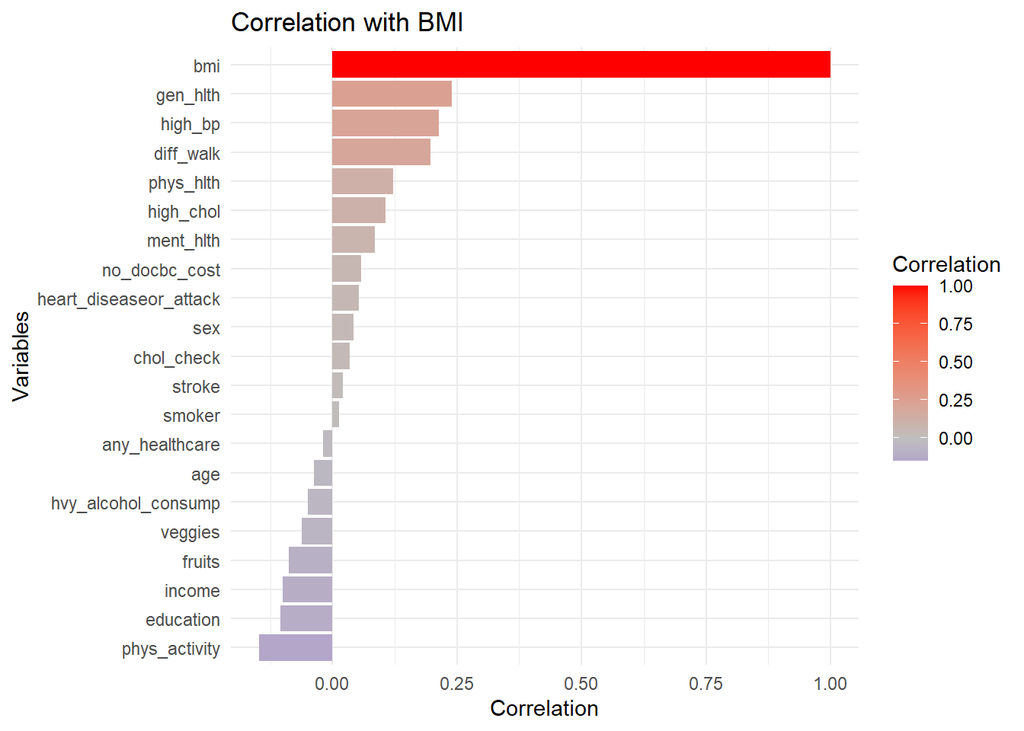

```r
# Vẽ ma trận tương quan các biến với BMI
# Tính ma trận tương quan chỉ với các biến số
cor_matrix <- cor(data_no_diabetes[sapply(data_no_diabetes, is.numeric)])

# Lấy giá trị tương quan với BMI
cor_bmi <- cor_matrix["bmi", ]

# Chuyển thành dataframe để vẽ
cor_bmi_df <- data.frame(Variable = names(cor_bmi), Correlation = cor_bmi)

ggplot(cor_bmi_df, aes(x = reorder(Variable, Correlation), y = Correlation, fill = Correlation)) +
  geom_bar(stat = "identity") +
  coord_flip() +  # Xoay trục để các biến hiển thị dọc
  scale_fill_gradient2(low = "blue", mid = "gray", high = "red", midpoint = 0) +
  labs(title = "Correlation with BMI", x = "Variables", y = "Correlation") +
  theme_minimal()
```

- Nhận xét chung:
  - Gen_hlth có tương quan cao nhất với BMI và là yếu tố quan trọng ảnh hưởng đến BMI => Điều này hợp lý vì sức khỏe tổng quát thường phản ánh các yếu tố liên quan đến cân nặng và lối sống.
  - High_bp và Diff_walk: Hai yếu tố này có mối tương quan đáng kể với BMI =>cho thấy những người có BMI cao thường gặp các vấn đề về huyết áp và khả năng di chuyển.
  - Phys_hlth và High_chol: Cũng có mối quan hệ đáng kể với BMI => Điều này hợp lý vì BMI cao có thể dẫn đến các vấn đề sức khỏe như cholesterol cao và sức khỏe thể chất suy giảm.
  - Nhóm yếu tố có tương quan thấp với BMI: Phys_activity, Education, Income, và Fruits có tương quan rất thấp, gần như không ảnh hưởng đáng kể đến BMI.
  - Các yếu tố tương quan âm với BMI:Phys_activity có tương quan âm nhẹ, cho thấy người hoạt động thể chất nhiều có xu hướng BMI thấp hơn.

### 2.3 Kiểm tra đa cộng tuyến

```r
md_bmi <- lm(bmi ~ ., data = data_no_diabetes)
vif(md_bmi)
```

```
##                high_bp              high_chol             chol_check
##               1.293597               1.170686               1.032466
##                 smoker                 stroke heart_diseaseor_attack
##               1.090655               1.079908               1.171409
##          phys_activity                 fruits                veggies
##               1.151437               1.110913               1.112380
##    hvy_alcohol_consump         any_healthcare          no_docbc_cost
##               1.022067               1.113100               1.144138
##               gen_hlth              ment_hlth              phys_hlth
##               1.769277               1.239289               1.621065
##              diff_walk                    sex                    age
##               1.515696               1.073375               1.324036
##              education                 income
##               1.325518               1.503601
```

Tất cả các biến đều có VIF <5, không bị xuất hiện đa cộng tuyến trong mô hình

### 2.4 Chuyển các biến phân loại sang factor

```r
categorical_columns <- c("high_bp", "high_chol", "chol_check", "smoker","stroke",
                         "heart_diseaseor_attack", "phys_activity", "fruits",
                         "veggies", "hvy_alcohol_consump", "any_healthcare",
                         "no_docbc_cost", "diff_walk", "sex", "gen_hlth","age", "education",                          "income")
data_no_diabetes <- data_no_diabetes %>% mutate(across(all_of(categorical_columns), as.factor))
str(data_no_diabetes)
```

```
## 'data.frame':    253680 obs. of  21 variables:
##  $ high_bp               : Factor w/ 2 levels "0","1": 2 1 2 2 2 2 2 2 2 1 ...
##  $ high_chol             : Factor w/ 2 levels "0","1": 2 1 2 1 2 2 1 2 2 1 ...
##  $ chol_check            : Factor w/ 2 levels "0","1": 2 1 2 2 2 2 2 2 2 2 ...
##  $ bmi                   : num  40 25 28 27 24 25 30 25 30 24 ...
##  $ smoker                : Factor w/ 2 levels "0","1": 2 2 1 1 1 2 2 2 2 1 ...
##  $ stroke                : Factor w/ 2 levels "0","1": 1 1 1 1 1 1 1 1 1 1 ...
##  $ heart_diseaseor_attack: Factor w/ 2 levels "0","1": 1 1 1 1 1 1 1 1 2 1 ...
##  $ phys_activity         : Factor w/ 2 levels "0","1": 1 2 1 2 2 2 1 2 1 1 ...
##  $ fruits                : Factor w/ 2 levels "0","1": 1 1 2 2 2 2 1 1 2 1 ...
##  $ veggies               : Factor w/ 2 levels "0","1": 2 1 1 2 2 2 1 2 2 2 ...
##  $ hvy_alcohol_consump   : Factor w/ 2 levels "0","1": 1 1 1 1 1 1 1 1 1 1 ...
##  $ any_healthcare        : Factor w/ 2 levels "0","1": 2 1 2 2 2 2 2 2 2 2 ...
##  $ no_docbc_cost         : Factor w/ 2 levels "0","1": 1 2 2 1 1 1 1 1 1 1 ...
##  $ gen_hlth              : Factor w/ 5 levels "1","2","3","4",..: 5 3 5 2 2 2 3 3 5 2 ...
##  $ ment_hlth             : num  18 0 30 0 3 0 0 0 30 0 ...
##  $ phys_hlth             : num  15 0 30 0 0 2 14 0 30 0 ...
##  $ diff_walk             : Factor w/ 2 levels "0","1": 2 1 2 1 1 1 1 2 2 1 ...
##  $ sex                   : Factor w/ 2 levels "0","1": 1 1 1 1 1 2 1 1 1 2 ...
##  $ age                   : Factor w/ 13 levels "1","2","3","4",..: 9 7 9 11 11 10 9 11 9 8 ...
##  $ education             : Factor w/ 6 levels "1","2","3","4",..: 4 6 4 3 5 6 6 4 5 4 ...
##  $ income                : Factor w/ 8 levels "1","2","3","4",..: 3 1 8 6 4 8 7 4 1 3 ...
```

## 3. Xây dựng mô hình ban đầu

```r
md_base_bmi <- lm(bmi ~ ., data = data_no_diabetes)
summary(md_base_bmi)
```

```
##
## Call:
## lm(formula = bmi ~ ., data = data_no_diabetes)
##
## Residuals:
##     Min      1Q  Median      3Q     Max
## -20.895  -3.758  -0.790   2.737  72.508
##
## Coefficients:
##                          Estimate Std. Error t value Pr(>|t|)
## (Intercept)             24.467380   0.480972  50.871  < 2e-16 ***
## high_bp1                 2.310953   0.027981  82.591  < 2e-16 ***
## high_chol1               0.495682   0.026699  18.566  < 2e-16 ***
## chol_check1              0.721922   0.065114  11.087  < 2e-16 ***
## smoker1                 -0.579998   0.025708 -22.561  < 2e-16 ***
## stroke1                 -0.848838   0.064032 -13.256  < 2e-16 ***
## heart_diseaseor_attack1 -0.152823   0.045240  -3.378 0.000730 ***
## phys_activity1          -1.080547   0.030391 -35.555  < 2e-16 ***
## fruits1                 -0.400985   0.026625 -15.060  < 2e-16 ***
## veggies1                -0.036066   0.032743  -1.101 0.270687
## hvy_alcohol_consump1    -1.170489   0.053308 -21.957  < 2e-16 ***
## any_healthcare1          0.127056   0.059491   2.136 0.032702 *
## no_docbc_cost1          -0.052247   0.046880  -1.114 0.265077
## gen_hlth2                1.400341   0.035760  39.160  < 2e-16 ***
## gen_hlth3                2.591591   0.038705  66.958  < 2e-16 ***
## gen_hlth4                2.845948   0.053277  53.418  < 2e-16 ***
## gen_hlth5                2.099401   0.080177  26.185  < 2e-16 ***
## ment_hlth               -0.001605   0.001829  -0.877 0.380309
## phys_hlth               -0.014945   0.001868  -8.001 1.24e-15 ***
## diff_walk1               2.443982   0.040265  60.697  < 2e-16 ***
## sex1                     0.599627   0.025391  23.616  < 2e-16 ***
## age2                     1.605136   0.107501  14.931  < 2e-16 ***
## age3                     2.372599   0.100227  23.672  < 2e-16 ***
## age4                     2.350743   0.097154  24.196  < 2e-16 ***
## age5                     2.428803   0.095252  25.499  < 2e-16 ***
## age6                     2.219698   0.093099  23.842  < 2e-16 ***
## age7                     1.809610   0.090753  19.940  < 2e-16 ***
## age8                     1.467969   0.089951  16.320  < 2e-16 ***
## age9                     1.036483   0.089786  11.544  < 2e-16 ***
## age10                    0.736365   0.090578   8.130 4.33e-16 ***
## age11                   -0.036060   0.093357  -0.386 0.699300
## age12                   -0.943121   0.097496  -9.673  < 2e-16 ***
## age13                   -2.594534   0.096916 -26.771  < 2e-16 ***
## education2              -0.238475   0.473446  -0.504 0.614471
## education3              -0.056255   0.467876  -0.120 0.904297
## education4               0.006865   0.464471   0.015 0.988208
## education5               0.155579   0.464534   0.335 0.737691
## education6              -0.520256   0.464612  -1.120 0.262816
## income2                  0.334923   0.083842   3.995 6.48e-05 ***
## income3                  0.265542   0.079038   3.360 0.000781 ***
## income4                  0.339543   0.076525   4.437 9.13e-06 ***
## income5                  0.451949   0.074517   6.065 1.32e-09 ***
## income6                  0.499198   0.072497   6.886 5.76e-12 ***
## income7                  0.459987   0.072277   6.364 1.97e-10 ***
## income8                  0.033280   0.070861   0.470 0.638607
## ---
## Signif. codes:  0 '***' 0.001 '**' 0.01 '*' 0.05 '.' 0.1 ' ' 1
##
## Residual standard error: 6.114 on 253635 degrees of freedom
## Multiple R-squared:  0.1443, Adjusted R-squared:  0.1441
## F-statistic: 971.9 on 44 and 253635 DF,  p-value: < 2.2e-16
```

- Nhận xét mô hình ban đầu
1. Đánh giá tổng thể mô hình
- R^2=0.1443: Chỉ 14.43% sự biến thiên của BMI được giải thích bởi các biến độc lập trong mô hình.

2.Biến có ý nghĩa thống kê (p < 0.05): - Các biến như high_bp, high_chol, phys_activity, gen_hlth, diff_walk, và nhiều cấp độ của age và income đều có ý nghĩa thống kê cao(p<0.001). => Đây là những biến quan trọng cần giữ lại trong mô hình.

### 3.1 Bỏ biến no_docbc_cost ra khỏi mô hình và xem xét R^2 của mô hình

```r
md_bmi_ <- lm(bmi ~ high_bp + high_chol + chol_check + smoker + stroke                        + heart_diseaseor_attack + phys_activity + fruits +                            veggies + hvy_alcohol_consump + any_healthcare + gen_hlth +
                       ment_hlth + phys_hlth + diff_walk + age + sex + education                       + income, data = data_no_diabetes)
summary(md_bmi)
```

[output not shown]

Tiếp theo, nhóm em sẽ Xây dựng mô hình hồi quy với tất cả các tương tác bậc 2 để kiểm tra xem cặp biến tiềm năng nào có ý nghĩa thống kê (p_val <0.05)

```r
md_bmi_interaction <- lm(bmi ~ (high_bp + high_chol + chol_check + smoker +
                           stroke + heart_diseaseor_attack + phys_activity
                         + fruits + veggies + hvy_alcohol_consump +
                           any_healthcare + gen_hlth +ment_hlth + phys_hlth
                         + diff_walk + age + sex + education + income)^2,
                         data = data_no_diabetes)
summary(md_bmi_interaction)
```

```
##
## Call:
## lm(formula = bmi ~ (high_bp + high_chol + chol_check + smoker +
##     stroke + heart_diseaseor_attack + phys_activity + fruits +
##     veggies + hvy_alcohol_consump + any_healthcare + gen_hlth +
##     ment_hlth + phys_hlth + diff_walk + age + sex + education +
##     income)^2, data = data_no_diabetes)
##
## Residuals:
##     Min      1Q  Median      3Q     Max
## -21.673  -3.626  -0.762   2.667  72.382
##
## Coefficients:
##                                                Estimate Std. Error t value
## (Intercept)                                   2.201e+01  4.843e+00   4.544
## high_bp1                                      3.485e+00  1.142e+00   3.053
## high_chol1                                    2.792e+00  1.180e+00   2.366
## chol_check1                                  -1.779e-01  2.641e+00  -0.067
## smoker1                                      -5.126e-01  1.188e+00  -0.431
## stroke1                                      -8.073e-01  2.607e+00  -0.310
## heart_diseaseor_attack1                      -2.750e+00  2.020e+00  -1.362
## phys_activity1                               -9.266e-01  1.108e+00  -0.836
## fruits1                                       3.008e+00  1.134e+00   2.652
## veggies1                                     -8.084e-01  1.269e+00  -0.637
## hvy_alcohol_consump1                         -5.624e+00  2.694e+00  -2.087
## any_healthcare1                              -3.979e-01  1.512e+00  -0.263
## gen_hlth2                                     1.034e-01  2.637e+00   0.039
## gen_hlth3                                    -3.953e-01  2.535e+00  -0.156
## gen_hlth4                                     7.066e-01  2.558e+00   0.276
## gen_hlth5                                    -1.371e+00  3.183e+00  -0.431
## ment_hlth                                     8.114e-02  6.171e-02   1.315
## phys_hlth                                     7.255e-02  5.923e-02   1.225
## diff_walk1                                    4.508e+00  1.597e+00   2.822
## age2                                          4.566e+00  7.202e+00   0.634
## age3                                          6.366e+00  4.363e+00   1.459
## age4                                          2.612e-01  4.202e+00   0.062
## age5                                         -3.010e+00  4.026e+00  -0.748
## age6                                          6.255e+00  4.038e+00   1.549
## age7                                          2.898e+00  3.818e+00   0.759
## age8                                          3.910e+00  3.807e+00   1.027
```

[output cut: 1654 more lines]

```
## education3:income7                           0.901127
## education4:income7                           0.992314
## education5:income7                           0.901469
## education6:income7                           0.852605
## education2:income8                           0.653865
## education3:income8                           0.837601
## education4:income8                           0.785905
## education5:income8                           0.904839
## education6:income8                           0.907725
## ---
## Signif. codes:  0 '***' 0.001 '**' 0.01 '*' 0.05 '.' 0.1 ' ' 1
##
## Residual standard error: 6.026 on 252836 degrees of freedom
## Multiple R-squared:  0.1715, Adjusted R-squared:  0.1687
## F-statistic: 62.07 on 843 and 252836 DF,  p-value: < 2.2e-16
```

Chúng ta sẽ chọn các biến tương tác có p_val <0.05: high_bp:high_chol, high_bp:chol_check, high_bp:phys_activity, high_bp:hvy_alcohol_consump, high_bp:gen_hlth, high_bp:diff_walk, high_chol:smoker, high_chol:phys_hlth, smoker:fruits, smoker:veggies, smoker:gen_hlth, smoker:diff_walk, chol_check:gen_hlth, chol_check:age, stroke:gen_hlth, stroke:phys_hlth

### 3.2 Kiểm tra các biến tương tác trong mô hình ban đầu

Bây giờ chúng ta sẽ tiến hành kiểm tra các biến tương tác này có thật sự ảnh hưởng đến BMI không

```r
# Hàm kiểm tra tương tác
evaluate_interaction <- function(interaction_term, data) {
  # Tách các biến tương tác
  interaction_vars <- strsplit(interaction_term, ":")[[1]]

  # Xử lý tên biến nếu là factor
  interaction_vars <- sapply(interaction_vars, function(var) {
    if (is.factor(data[[var]])) {
      paste0(var, levels(data[[var]])[2])
    } else {
      var
    }
  })

  # Ghép lại tên biến tương tác
  interaction_term_formatted <- paste(interaction_vars, collapse = ":")

  # Xây dựng công thức
  formula <- as.formula(paste("bmi ~", interaction_term, "+ high_bp + high_chol + chol_check + smoker + stroke + ",
                              "heart_diseaseor_attack + phys_activity + fruits + veggies + ",
                              "hvy_alcohol_consump + any_healthcare + gen_hlth + ment_hlth + ",
                              "phys_hlth + diff_walk + age + sex + education + income"))

  # Chạy mô hình
  model <- lm(formula, data = data)
  summary_model <- summary(model)

  # Kiểm tra nếu biến tương tác tồn tại trong bảng coefficients
  if (interaction_term_formatted %in% rownames(summary_model$coefficients)) {
    p_value <- summary_model$coefficients[interaction_term_formatted, "Pr(>|t|)"]
  } else {
    p_value <- NA  # Gán NA nếu không tồn tại
  }

  return(list(term = interaction_term, p_value = p_value))
}

# Danh sách các biến tương tác cần kiểm tra
interaction_terms <- c(
  "high_bp:high_chol", "high_bp:chol_check", "high_bp:phys_activity", "high_bp:hvy_alcohol_consump",
  "high_bp:gen_hlth", "high_bp:diff_walk", "high_chol:smoker", "high_chol:phys_hlth",
  "smoker:fruits", "smoker:veggies", "smoker:gen_hlth", "smoker:diff_walk",
  "chol_check:gen_hlth", "chol_check:age", "stroke:gen_hlth", "stroke:phys_hlth"
)

# Chạy kiểm tra từng biến tương tác
results <- lapply(interaction_terms, evaluate_interaction, data = data_no_diabetes)

# Chuyển kết quả thành dataframe để xem
results_df <- do.call(rbind, lapply(results, as.data.frame))

# In kết quả
print(results_df)
```

```
##                           term      p_value
## 1            high_bp:high_chol 2.272864e-42
## 2           high_bp:chol_check 2.365468e-04
## 3        high_bp:phys_activity 2.548809e-05
## 4  high_bp:hvy_alcohol_consump 2.966526e-21
## 5             high_bp:gen_hlth 2.588721e-02
## 6            high_bp:diff_walk 5.065241e-10
## 7             high_chol:smoker 1.918236e-02
## 8          high_chol:phys_hlth 5.422164e-02
## 9                smoker:fruits 1.883353e-37
## 10              smoker:veggies 2.817297e-42
## 11             smoker:gen_hlth 5.718137e-15
## 12            smoker:diff_walk 6.518288e-86
## 13         chol_check:gen_hlth 3.466144e-01
## 14              chol_check:age 2.048817e-02
## 15             stroke:gen_hlth 1.517443e-02
## 16            stroke:phys_hlth 5.423444e-01
```

### 3.3 Xây dựng mô hình mới

Ta sẽ đưa các biến tương tác vừa tìm được để xây dựng mô hình mới

```r
md_bmi_update <- lm(bmi ~ high_bp*high_chol + high_bp*phys_activity +           high_bp*hvy_alcohol_consump + high_bp*gen_hlth + high_bp*diff_walk + high_chol*smoker + smoker*fruits + smoker*veggies + smoker*gen_hlth + smoker*diff_walk + chol_check*age + stroke*gen_hlth + stroke*phys_hlth +        heart_diseaseor_attack + education + income + sex,
  data = data_no_diabetes
)
summary(md_bmi_update)
```

```
##
## Call:
## lm(formula = bmi ~ high_bp * high_chol + high_bp * phys_activity +
##     high_bp * hvy_alcohol_consump + high_bp * gen_hlth + high_bp *
##     diff_walk + high_chol * smoker + smoker * fruits + smoker *
##     veggies + smoker * gen_hlth + smoker * diff_walk + chol_check *
##     age + stroke * gen_hlth + stroke * phys_hlth + heart_diseaseor_attack +
##     education + income + sex, data = data_no_diabetes)
##
## Residuals:
##     Min      1Q  Median      3Q     Max
## -21.691  -3.745  -0.792   2.716  71.831
##
## Coefficients:
##                                Estimate Std. Error t value Pr(>|t|)
## (Intercept)                   25.481077   0.603094  42.251  < 2e-16 ***
## high_bp1                       2.779247   0.091901  30.242  < 2e-16 ***
## high_chol1                     0.737920   0.042304  17.443  < 2e-16 ***
## phys_activity1                -0.992246   0.042391 -23.407  < 2e-16 ***
## hvy_alcohol_consump1          -0.820993   0.069625 -11.792  < 2e-16 ***
## gen_hlth2                      1.557174   0.048172  32.326  < 2e-16 ***
## gen_hlth3                      3.020666   0.054796  55.126  < 2e-16 ***
## gen_hlth4                      3.463463   0.086449  40.064  < 2e-16 ***
## gen_hlth5                      2.315723   0.147825  15.665  < 2e-16 ***
## diff_walk1                     2.699322   0.075276  35.859  < 2e-16 ***
## smoker1                       -0.479442   0.087061  -5.507 3.65e-08 ***
## fruits1                       -0.596988   0.036060 -16.555  < 2e-16 ***
## veggies1                      -0.280882   0.044487  -6.314 2.73e-10 ***
## chol_check1                   -0.550834   0.387134  -1.423 0.154780
## age2                           0.518685   0.472455   1.098 0.272271
## age3                           1.290425   0.435655   2.962 0.003056 **
## age4                           1.098035   0.426146   2.577 0.009977 **
## age5                           1.032245   0.428947   2.406 0.016109 *
## age6                           0.457386   0.422235   1.083 0.278698
## age7                           0.579716   0.417109   1.390 0.164578
## age8                           0.112770   0.415937   0.271 0.786296
## age9                          -0.240195   0.421147  -0.570 0.568451
## age10                         -0.613480   0.447018  -1.372 0.169945
## age11                         -0.892813   0.501402  -1.781 0.074974 .
## age12                         -1.689536   0.563903  -2.996 0.002734 **
```

[output cut: 41 more lines]

```
## chol_check1:age10              1.361916   0.455861   2.988 0.002812 **
## chol_check1:age11              0.853272   0.509605   1.674 0.094057 .
## chol_check1:age12              0.730352   0.571770   1.277 0.201479
## chol_check1:age13              0.942287   0.546379   1.725 0.084601 .
## gen_hlth2:stroke1             -0.646102   0.328724  -1.965 0.049359 *
## gen_hlth3:stroke1             -1.723113   0.312843  -5.508 3.63e-08 ***
## gen_hlth4:stroke1             -1.960970   0.323261  -6.066 1.31e-09 ***
## gen_hlth5:stroke1             -1.829538   0.359334  -5.091 3.56e-07 ***
## stroke1:phys_hlth              0.011434   0.006578   1.738 0.082196 .
## ---
## Signif. codes:  0 '***' 0.001 '**' 0.01 '*' 0.05 '.' 0.1 ' ' 1
##
## Residual standard error: 6.097 on 253605 degrees of freedom
## Multiple R-squared:  0.149,  Adjusted R-squared:  0.1488
## F-statistic: 600.1 on 74 and 253605 DF,  p-value: < 2.2e-16
```

## 4. Lựa chọn mô hình

```r
# Sử dụng model.matrix để chuyển các biến factor sang dạng dummy
data_no_diabetes_dummy <- model.matrix(
  ~ high_bp * high_chol + high_bp * phys_activity + high_bp * hvy_alcohol_consump +
    high_bp * gen_hlth + high_bp * diff_walk + high_chol * smoker +
    smoker * fruits + smoker * veggies + smoker * gen_hlth +
    smoker * diff_walk + chol_check * age + stroke * gen_hlth + stroke * phys_hlth +
    heart_diseaseor_attack + education + income + sex - 1,  # -1 để loại bỏ intercept tự động
  data = data_no_diabetes
)

# Chuyển đổi ma trận sang data frame
data_no_diabetes_dummy <- as.data.frame(data_no_diabetes_dummy)
data_no_diabetes_dummy$bmi <- data_no_diabetes$bmi  # Thêm biến phụ thuộc
library(leaps)

# Áp dụng regsubsets với dữ liệu đã chuyển đổi
out_subset_bmi <- regsubsets(
  bmi ~ .,
  data = data_no_diabetes_dummy,
  nvmax = 20,  # Số lượng biến tối đa
  method = "seqrep"
)
```

```
## Reordering variables and trying again:
```

```r
# Tóm tắt kết quả
summary_subset <- summary(out_subset_bmi)

# Xem giá trị Mallows' Cp
cp_values <- summary_subset$cp
print("Mallows' Cp values:")
```

```
## [1] "Mallows' Cp values:"
```

```r
print(cp_values)
```

```
##  [1] 30718.394 23729.846 18370.619 15766.546 13513.699 11610.587  9781.702
##  [8]  8543.680  7378.873  6594.268  5934.625  5353.287  4783.190  4252.250
## [15]  3759.619  3329.704  3002.689  2774.961  2565.262  2347.364  2163.195
```

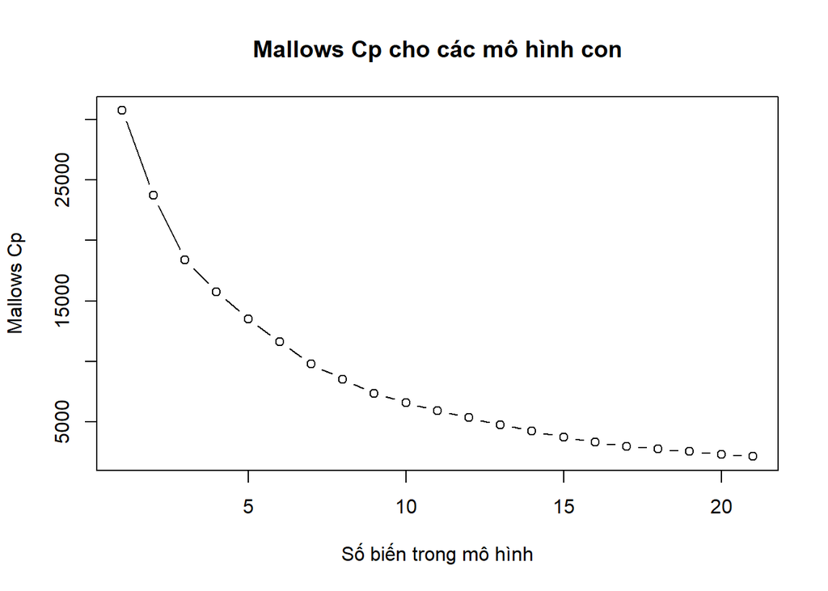

```r
# Vẽ biểu đồ Mallows' Cp
plot(
  cp_values,
  type = "b",
  xlab = "Số biến trong mô hình",
  ylab = "Mallows Cp",
  main = "Mallows Cp cho các mô hình con"
)
abline(a = 0, b = 1, col = "red", lty = 2)  # Đường tham chiếu y = x
```

```r
# Tìm số biến tối ưu
best_model_index <- which.min(cp_values)
print(paste("Số biến trong mô hình tốt nhất:", best_model_index))
```

```
## [1] "Số biến trong mô hình tốt nhất: 21"
```

```r
# Lấy các biến trong mô hình tốt nhất
best_model_variables <- coef(out_subset_bmi, best_model_index)
print("Các biến trong mô hình tốt nhất:")
```

```
## [1] "Các biến trong mô hình tốt nhất:"
```

```r
print(best_model_variables)
```

```
##               (Intercept)                high_chol1            phys_activity1
##               28.21719175                0.59303358               -2.20264877
##      hvy_alcohol_consump1                 gen_hlth2                 gen_hlth3
##               -1.22551048                1.54856868                2.93756785
##                 gen_hlth4                 gen_hlth5                   smoker1
##                3.88185609                2.46549047               -0.24556272
##                  veggies1                      age9                     age10
##               -0.26338326               -0.71582721               -0.96594666
##                     age11                     age12                     age13
##               -1.69597839               -2.57586310               -4.22656605
##                   stroke1                   income2     `high_bp1:high_chol1`
##               -0.80472260                0.08407479                0.00719128
## `high_bp1:phys_activity1`     `high_bp1:diff_walk1`       `gen_hlth4:smoker1`
##                1.91411005                2.76881383               -1.06770253
##        `chol_check1:age2`
##               -0.27992427
```

```r
# Tạo công thức mô hình
best_model_formula <- as.formula(
  paste("bmi ~", paste(names(best_model_variables[-1]), collapse = " + "))
)
print("Công thức mô hình tốt nhất:")
```

```
## [1] "Công thức mô hình tốt nhất:"
```

```r
print(best_model_formula)
```

```
## bmi ~ high_chol1 + phys_activity1 + hvy_alcohol_consump1 + gen_hlth2 +
##     gen_hlth3 + gen_hlth4 + gen_hlth5 + smoker1 + veggies1 +
##     age9 + age10 + age11 + age12 + age13 + stroke1 + income2 +
##     `high_bp1:high_chol1` + `high_bp1:phys_activity1` + `high_bp1:diff_walk1` +
##     `gen_hlth4:smoker1` + `chol_check1:age2`
```

```r
# Xây dựng mô hình tốt nhất
md_bmi_best <- lm(best_model_formula, data = data_no_diabetes_dummy)

# Tóm tắt mô hình tốt nhất
summary(md_bmi_best)
```

```
##
## Call:
## lm(formula = best_model_formula, data = data_no_diabetes_dummy)
##
## Residuals:
##     Min      1Q  Median      3Q     Max
## -21.180  -3.774  -0.769   2.752  72.929
##
## Coefficients:
##                            Estimate Std. Error t value Pr(>|t|)
## (Intercept)               28.217192   0.050193 562.175  < 2e-16 ***
## high_chol1                 0.593034   0.035348  16.777  < 2e-16 ***
## phys_activity1            -2.202649   0.035211 -62.555  < 2e-16 ***
## hvy_alcohol_consump1      -1.225510   0.053663 -22.837  < 2e-16 ***
## gen_hlth2                  1.548569   0.036036  42.973  < 2e-16 ***
## gen_hlth3                  2.937568   0.038268  76.764  < 2e-16 ***
## gen_hlth4                  3.881856   0.062956  61.660  < 2e-16 ***
## gen_hlth5                  2.465490   0.069543  35.453  < 2e-16 ***
## smoker1                   -0.245563   0.027150  -9.045  < 2e-16 ***
## veggies1                  -0.263383   0.031874  -8.263  < 2e-16 ***
## age9                      -0.715827   0.038633 -18.529  < 2e-16 ***
## age10                     -0.965947   0.039488 -24.462  < 2e-16 ***
## age11                     -1.695978   0.044962 -37.720  < 2e-16 ***
## age12                     -2.575863   0.052895 -48.697  < 2e-16 ***
## age13                     -4.226566   0.051230 -82.501  < 2e-16 ***
## stroke1                   -0.804723   0.064102 -12.554  < 2e-16 ***
## income2                    0.084075   0.059506   1.413 0.157693
## `high_bp1:high_chol1`      0.007191   0.047569   0.151 0.879838
## `high_bp1:phys_activity1`  1.914110   0.037080  51.621  < 2e-16 ***
## `high_bp1:diff_walk1`      2.768814   0.045399  60.988  < 2e-16 ***
## `gen_hlth4:smoker1`       -1.067703   0.074900 -14.255  < 2e-16 ***
## `chol_check1:age2`        -0.279924   0.075489  -3.708 0.000209 ***
## ---
## Signif. codes:  0 '***' 0.001 '**' 0.01 '*' 0.05 '.' 0.1 ' ' 1
##
## Residual standard error: 6.173 on 253658 degrees of freedom
## Multiple R-squared:  0.1275, Adjusted R-squared:  0.1275
## F-statistic:  1766 on 21 and 253658 DF,  p-value: < 2.2e-16
```

R^2 giảm so với mô hình ban đầu cho thấy vẫn chưa cải thiện hiệu suất

```r
set.seed(123)

# 10-fold cross-validation
error10 <- errorest(best_model_formula, data = data_no_diabetes_dummy, model = lm)$error

# 5-fold cross-validation
error5 <- errorest(best_model_formula, data = data_no_diabetes_dummy, model = lm, est.para = control.errorest(k = 5))$error

# 50-fold cross-validation
error50 <- errorest(best_model_formula, data = data_no_diabetes_dummy, model = lm, est.para = control.errorest(k = 50))$error

# Tổng hợp kết quả RMSE
cv_errors <- data.frame(
  k = c(5, 10, 50),
  RMSE = c(error5, error10, error50)
)
print("Sai số RMSE từ Cross-Validation:")
```

```
## [1] "Sai số RMSE từ Cross-Validation:"
```

```r
print(cv_errors)
```

```
##    k     RMSE
## 1  5 6.173496
## 2 10 6.173397
## 3 50 6.173497
```

=> Chúng ta vẫn sẽ giữ mô hình ban đầu

## 5. Chẩn đoán mô hình

### 5.1 Kiểm tra tính tuyến tính của mô hình

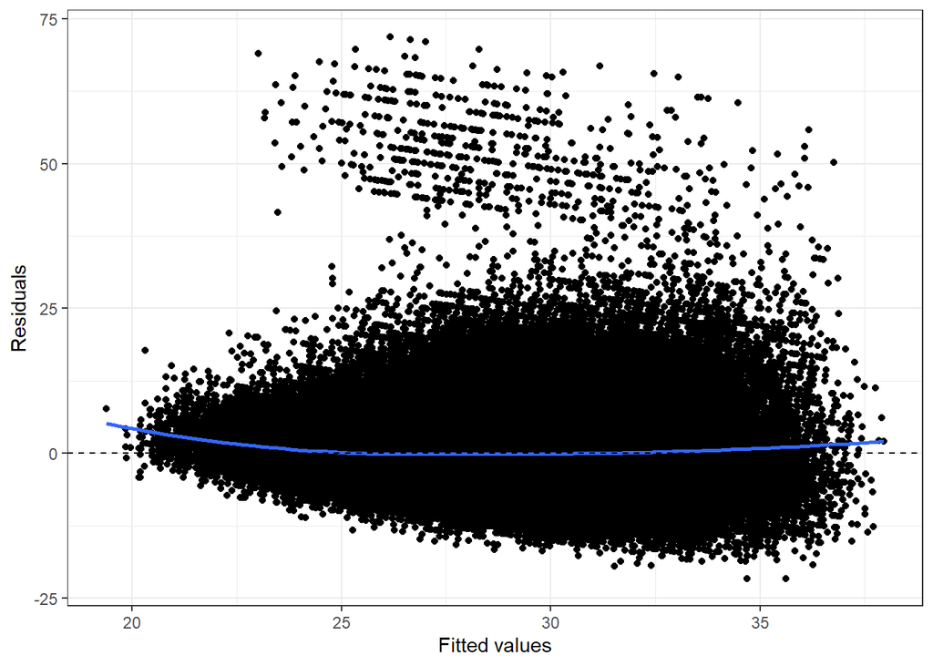

```r
ggplot(data = md_bmi_update, mapping = aes(x = .fitted, y= .resid)) +
  geom_point() +
  geom_smooth(method = "loess", se = FALSE) + # ve duong cong theo xu huong dl
  geom_hline(yintercept = 0, linetype = "dashed") +
  labs(x= "Fitted values", y= "Residuals") +
  theme_bw()
```

Nhận xét:

- Đường cong màu xanh cho thấy có sự dao động nhẹ xung quanh đường ngang tại giá trị 0.
- Mặc dù phần lớn các phần dư nằm khá đồng đều xung quanh giá trị 0, nhưng ở một số khu vực, đặc biệt ở phía đầu và cuối của giá trị Fitted Values, có dấu hiệu của sự không tuyến tính nhẹ.

### 5.2 Kiểm tra đồng nhất phương sai

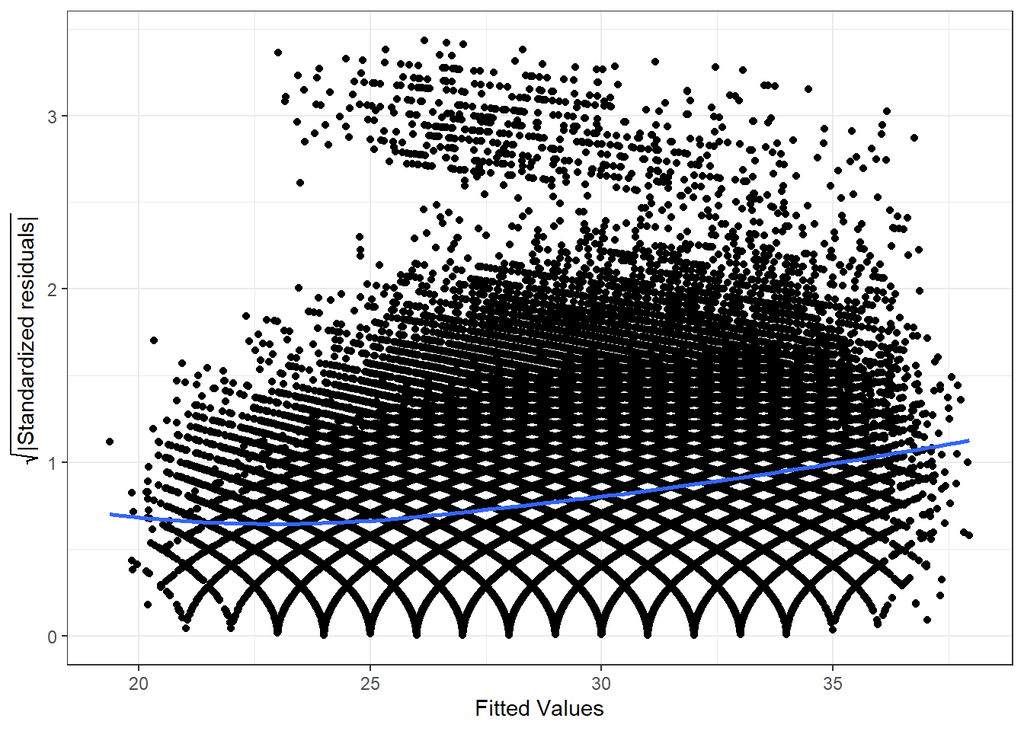

```r
ggplot(md_bmi_update, aes(x = .fitted, y = sqrt(abs(.stdresid)))) +
  geom_point(na.rm = TRUE) +
  geom_smooth(method = "loess", na.rm = TRUE, se = FALSE) +
  labs(x = "Fitted Values", y = expression(sqrt("|Standardized residuals|"))) +
  theme_bw()
```

### 5.3 Kiểm tra phân phối của phần dư

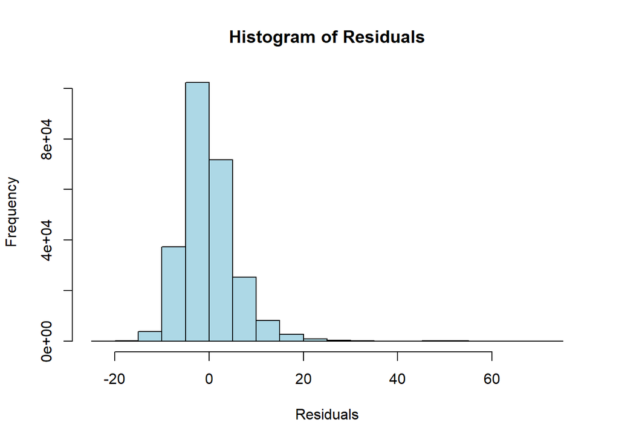

```r
# Phần dư từ mô hình
residuals <- resid(md_bmi_update)

# Histogram của phần dư
hist(residuals, breaks = 30, main = "Histogram of Residuals",
     xlab = "Residuals", col = "lightblue", border = "black")
```

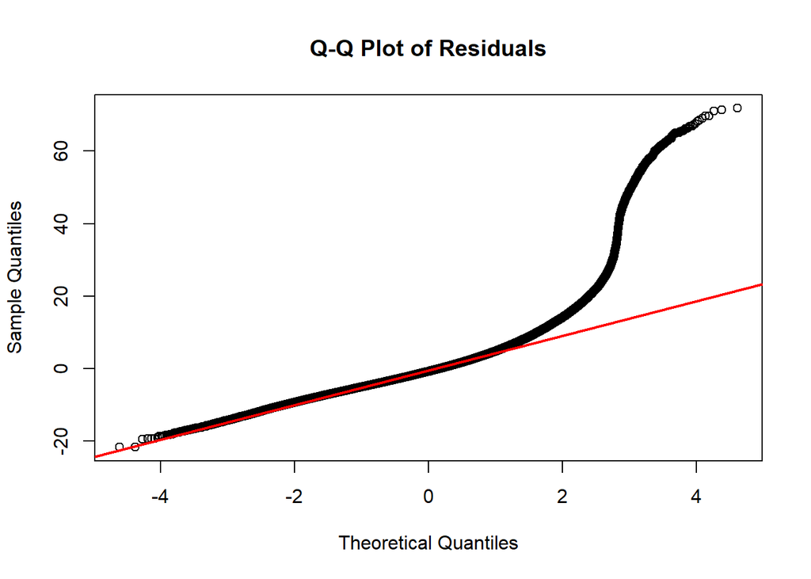

```r
# Q-Q Plot
qqnorm(residuals, main = "Q-Q Plot of Residuals")
qqline(residuals, col = "red", lwd = 2)
```

- Phần giữa của dữ liệu (gần trục 0 trên trục x):
  - Các điểm nằm khá sát đường thẳng màu đỏ (đường chuẩn lý thuyết)

    => Đây là dấu hiệu của phân phối không chuẩn ở phần đuôi => Vi phạm giả định phân phối chuẩn: Phân phối phần dư không hoàn toàn chuẩn, đặc biệt ở các giá trị cực đại và cực tiểu (đuôi dữ liệu).

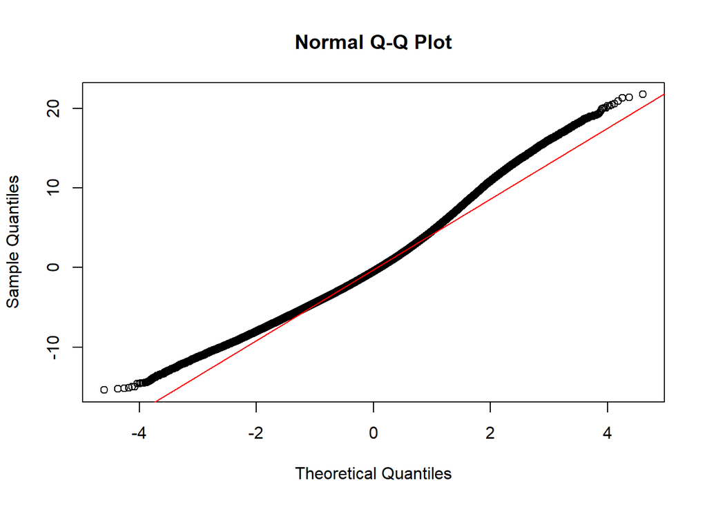

```r
# Xác định giá trị ngoại lai bằng Cook's Distance
cooks_dist <- cooks.distance(md_bmi_update)
outliers <- which(cooks_dist > (4 / nrow(data_no_diabetes)))

# Loại bỏ các dòng ngoại lai
data_no_outliers <- data_no_diabetes[-outliers, ]

# Chạy lại mô hình
md_bmi_no_outliers <- lm(bmi ~ high_bp*high_chol + high_bp*phys_activity +
                         high_bp*hvy_alcohol_consump + high_bp*gen_hlth +
                         high_bp*diff_walk + high_chol*smoker + smoker*fruits +
                         smoker*veggies + smoker*gen_hlth + smoker*diff_walk +
                         chol_check*age + stroke*gen_hlth + stroke*phys_hlth +
                         heart_diseaseor_attack + education + income + sex,
                         data = data_no_outliers)

# Kiểm tra lại phần dư
qqnorm(residuals(md_bmi_no_outliers))
qqline(residuals(md_bmi_no_outliers), col = "red")
```

## 6. Chạy lại mô hình hồi quy tuyến tính với data mới

```r
data_no_outliers <- data_no_diabetes[-outliers, ]
head(data_no_outliers)
```

```
##   high_bp high_chol chol_check bmi smoker stroke heart_diseaseor_attack
## 1       1         1          1  40      1      0                      0
## 2       0         0          0  25      1      0                      0
## 3       1         1          1  28      0      0                      0
## 4       1         0          1  27      0      0                      0
## 5       1         1          1  24      0      0                      0
## 6       1         1          1  25      1      0                      0
##   phys_activity fruits veggies hvy_alcohol_consump any_healthcare no_docbc_cost
## 1             0      0       1                   0              1             0
## 2             1      0       0                   0              0             1
## 3             0      1       0                   0              1             1
## 4             1      1       1                   0              1             0
## 5             1      1       1                   0              1             0
## 6             1      1       1                   0              1             0
##   gen_hlth ment_hlth phys_hlth diff_walk sex age education income
## 1        5        18        15         1   0   9         4      3
## 2        3         0         0         0   0   7         6      1
## 3        5        30        30         1   0   9         4      8
## 4        2         0         0         0   0  11         3      6
## 5        2         3         0         0   0  11         5      4
## 6        2         0         2         0   1  10         6      8
```

```r
# Chạy lại mô hình
final_md <- lm(bmi ~ high_bp*high_chol + high_bp*phys_activity +
                         high_bp*hvy_alcohol_consump + high_bp*gen_hlth +
                         high_bp*diff_walk + high_chol*smoker + smoker*fruits +
                         smoker*veggies + smoker*gen_hlth + smoker*diff_walk +
                         chol_check*age + stroke*gen_hlth + stroke*phys_hlth +
                         heart_diseaseor_attack + education + income + sex,
                         data = data_no_outliers)
summary(final_md)
```

```
##
## Call:
## lm(formula = bmi ~ high_bp * high_chol + high_bp * phys_activity +
##     high_bp * hvy_alcohol_consump + high_bp * gen_hlth + high_bp *
##     diff_walk + high_chol * smoker + smoker * fruits + smoker *
##     veggies + smoker * gen_hlth + smoker * diff_walk + chol_check *
##     age + stroke * gen_hlth + stroke * phys_hlth + heart_diseaseor_attack +
##     education + income + sex, data = data_no_outliers)
##
## Residuals:
##      Min       1Q   Median       3Q      Max
## -15.3976  -3.2482  -0.4971   2.7516  21.7434
##
## Coefficients:
##                                Estimate Std. Error t value Pr(>|t|)
## (Intercept)                   25.414886   0.803922  31.614  < 2e-16 ***
## high_bp1                       2.443137   0.071692  34.078  < 2e-16 ***
## high_chol1                     0.710481   0.032878  21.609  < 2e-16 ***
## phys_activity1                -0.848446   0.033333 -25.453  < 2e-16 ***
## hvy_alcohol_consump1          -0.798872   0.054215 -14.735  < 2e-16 ***
## gen_hlth2                      1.517646   0.037087  40.921  < 2e-16 ***
## gen_hlth3                      2.810059   0.042412  66.256  < 2e-16 ***
## gen_hlth4                      2.823272   0.068811  41.029  < 2e-16 ***
## gen_hlth5                      1.771397   0.124859  14.187  < 2e-16 ***
## diff_walk1                     2.226922   0.060569  36.767  < 2e-16 ***
## smoker1                       -0.469739   0.067923  -6.916 4.67e-12 ***
## fruits1                       -0.555535   0.028154 -19.732  < 2e-16 ***
## veggies1                      -0.214997   0.034946  -6.152 7.65e-10 ***
## chol_check1                   -1.078850   0.471528  -2.288 0.022139 *
## age2                           0.312608   0.544707   0.574 0.566035
## age3                           0.789147   0.505899   1.560 0.118787
## age4                           0.334936   0.496689   0.674 0.500098
## age5                           0.488966   0.500033   0.978 0.328141
## age6                           0.078545   0.492921   0.159 0.873397
## age7                           0.249724   0.490037   0.510 0.610331
## age8                          -0.214939   0.488775  -0.440 0.660119
## age9                          -0.370438   0.492036  -0.753 0.451531
## age10                         -0.621678   0.512203  -1.214 0.224850
## age11                         -0.710256   0.569354  -1.247 0.212224
## age12                         -1.589560   0.649699  -2.447 0.014421 *
```

[output cut: 41 more lines]

```
## chol_check1:age10              1.982905   0.516946   3.836 0.000125 ***
## chol_check1:age11              1.436193   0.573791   2.503 0.012316 *
## chol_check1:age12              1.494556   0.653922   2.286 0.022283 *
## chol_check1:age13              1.371337   0.604836   2.267 0.023374 *
## gen_hlth2:stroke1             -0.881260   0.299910  -2.938 0.003299 **
## gen_hlth3:stroke1             -1.768836   0.288113  -6.139 8.30e-10 ***
## gen_hlth4:stroke1             -1.585411   0.298281  -5.315 1.07e-07 ***
## gen_hlth5:stroke1             -1.470587   0.333608  -4.408 1.04e-05 ***
## stroke1:phys_hlth              0.011632   0.005816   2.000 0.045497 *
## ---
## Signif. codes:  0 '***' 0.001 '**' 0.01 '*' 0.05 '.' 0.1 ' ' 1
##
## Residual standard error: 4.647 on 241418 degrees of freedom
## Multiple R-squared:  0.1938, Adjusted R-squared:  0.1936
## F-statistic: 784.2 on 74 and 241418 DF,  p-value: < 2.2e-16
```

R^2 tăng lên đáng kể so với mô hình ban đầu, các thông số khác được nâng cao

=> Mô hình được cải thiện hiệu suất

# C. Nhận xét và đưa ra khuyến nghị với BMI

## 1. Về mô hình

### Nhận xét:

- Mô hình cuối cùng để kiểm tra sự tuyến tính của các biến khác lên BMI là

  final_md <- lm(bmi ~ high_bp * high_chol + high_bp * phys_activity + high_bp * hvy_alcohol_consump + high_bp * gen_hlth + high_bp * diff_walk + high_chol * smoker + smoker * fruits + smoker * veggies + smoker * *gen_hlth + smoker* diff_walk + chol_check * age + stroke * gen_hlth + stroke * phys_hlth + heart_diseaseor_attack + education + income + sex, data = data_no_outliers)
- High_bp (Huyết áp cao) tác động đến BMI thông qua các tương tác:
  - high_bp * high_chol: Huyết áp cao và cholesterol cao có thể cùng tăng nguy cơ ảnh hưởng đến BMI.
  - high_bp * phys_activity: Hoạt động thể chất giảm hoặc không đủ ở người huyết áp cao có thể làm tăng BMI.
  - high_bp * hvy_alcohol_consump: Tiêu thụ rượu nặng và huyết áp cao góp phần làm tăng BMI.
  - high_bp * gen_hlth: Sự kết hợp giữa huyết áp cao và sức khỏe tổng quát kém làm tăng BMI.
  - high_bp * diff_walk: Khó khăn trong đi lại kết hợp với huyết áp cao cũng là yếu tố đáng kể.
- High_chol (Cholesterol cao) kết hợp với hành vi hút thuốc (high_chol * smoker) ảnh hưởng đến BMI.
- Smoker (Hút thuốc lá) hút thuốc tác động đến BMI qua nhiều yếu tố khác: smoker * fruits: Việc hút thuốc và thiếu trái cây trong chế độ ăn góp phần làm thay đổi BMI.
  - smoker * veggies: Tương tự, sự thiếu rau củ cùng với hút thuốc làm tăng BMI.
  - smoker * gen_hlth: Sức khỏe tổng quát kém của người hút thuốc ảnh hưởng lớn đến BMI.
  - smoker * diff_walk: Khó khăn đi lại cũng có tác động tiêu cực khi kết hợp với hút thuốc.
- Chol_check (Kiểm tra cholesterol) kết hợp với tuổi (chol_check * age), cho thấy tuổi tác cùng tầm soát cholesterol có ảnh hưởng đến BMI.
- Stroke và Heart_diseaseor_attack (Đột quỵ và bệnh tim) những người từng bị đột quỵ hoặc bệnh tim có thể có BMI khác biệt do ảnh hưởng đến sức khỏe tổng quát và hoạt động thể chất.
- Education (Trình độ học vấn) trình độ học vấn có thể phản ánh thói quen sống lành mạnh hơn (ăn uống, hoạt động thể chất) và từ đó ảnh hưởng đến BMI.
- Income (Thu nhập) thu nhập cao có thể đi kèm với khả năng tiếp cận thực phẩm chất lượng hoặc chế độ sống lành mạnh hơn, ảnh hưởng đến BMI.
- Sex (Giới tính) ảnh hưởng đến BMI qua sự khác biệt về sinh học, hành vi, và các yếu tố văn hóa.

### Kết luận

- BMI chịu ảnh hưởng của nhiều yếu tố liên quan đến sức khỏe (như huyết áp, cholesterol, đột quỵ), hành vi cá nhân (như hút thuốc, tiêu thụ rượu, chế độ ăn), và các đặc điểm nhân khẩu học (giới tính, thu nhập, trình độ học vấn).
- Tương tác giữa các biến: Mô hình chỉ ra rằng nhiều yếu tố không chỉ ảnh hưởng trực tiếp đến BMI mà còn có sự tương tác phức tạp, ví dụ như sự kết hợp giữa huyết áp cao, cholesterol, và các hành vi lối sống.
- Tác động của sức khỏe tổng quát: Các biến như sức khỏe tổng quát (gen_hlth), khó khăn đi lại (diff_walk) phản ánh rõ rệt tác động của tình trạng sức khỏe chung lên BMI.

## 2. Khuyến nghị để cải thiện BMI

- Kiểm soát huyết áp và cholesterol
- Giảm hoặc ngừng hút thuốc
- Hạn chế tiêu thụ rượu bia
- Tăng cường hoạt động thể chất
- Cải thiện chế độ ăn uống
- Sống lành mạnh

## Classification

```r
data <- data[, !names(data) %in% c("gen_hlth", "income", "education", "age")]
data <- data |>
  mutate(across(c(
    diabetes_012, high_bp, high_chol, chol_check, smoker, stroke,
    heart_diseaseor_attack, phys_activity, fruits, veggies,
    hvy_alcohol_consump, any_healthcare, no_docbc_cost, diff_walk, sex
  ), as.factor))
```